# INFSCI 2595 Fall 2023 Homework: 03

Assigned September 13, 2023; Due: September 20, 2023

SOLUTION GUIDE

Submission time: September 20, 2023 at 11:00PM EST

#### Collaborators

Include the names of your collaborators here.

## Overview

This assignment is focused on binary classification performance metrics. You will calculate the Accuracy, the confusion matrix, and a simple ROC curve manually on a simple example. Afterwards, you will assess the performance of multiple binary classifiers using `caret` to manage the resampling process and the `yardstick` package to calculate several performance metrics in a more realistic application. You will use Accuracy, the ROC curve, and the ROC AUC to compare multiple models and select the best one. Lastly, you will compare the models using the calibration curve.

**IMPORTANT**: The RMarkdown assumes you have downloaded the 3 data sets (CSV files) to the same directory you saved the template Rmarkdown file. If you do not have the 3 CSV files in the correct location, the data will not be loaded correctly.

### IMPORTANT!!!

Certain code chunks are created for you. Each code chunk has `eval=FALSE` set in the chunk options. You **MUST** change it to be `eval=TRUE` in order for the code chunks to be evaluated when rendering the document.

You are free to add more code chunks if you would like.

## Load packages

The tidyverse is loaded for you in the code chunk below.

```r
library(tidyverse)
```

The other packages, `caret` and `yardstick`, will be loaded as needed later in the assignment.

## Problem 01

The code chunk below reads in a data set that you will work with in Problems 1, 2 and 3. A glimpse is printed for you which shows three variables, an input `x`, a model predicted event probability, `pred_prob`, and the observed output class, `obs_class`. A binary classifier has already been trained for you. That model’s predicted probability (`pred_prob`) is provided with the observed binary outcome (`obs_class`). You will use this data set to get experience with binary classification performance metrics.

```r
example_data_path <- "hw03_example_binary_data.csv"

model_pred_df <- readr::read_csv(example_data_path, col_names = TRUE)
model_pred_df %>% glimpse()
```

```
## Rows: 125
## Columns: 3
## $ x         <dbl> -0.4574291, 0.4259475, -0.7846951, -1.9252092, 2.2526171, 1.…
## $ pred_prob <dbl> 0.4174307, 0.2236508, 0.5987937, 0.9903552, 0.8607660, 0.491…
## $ obs_class <chr> "non_event", "non_event", "event", "event", "event", "non_ev…
```

### 1a)

**Pipe the `model_pred_df` data set into the `count()` function to display the number of unique values of the `obs_class` variable.**

#### SOLUTION

```r
model_pred_df %>% count(obs_class)
```

```
## # A tibble: 2 × 2
##   obs_class     n
##   <chr>     <int>
## 1 event        66
## 2 non_event    59
```

### 1b)

You should see that one of the values of `obs_class` is the event of interest and is named `"event"`.

**Use the `mean()` function to determine the fraction (or proportion) of the observations that correspond to the event of interest. Is the data set a balanced data set?**

#### SOLUTION

As shown by the print out below, about 53% of the observations in the data set correspond to the event. So yes, this is a balanced data set.

```r
mean(model_pred_df$obs_class == "event")
```

```
## [1] 0.528
```

The same result can be calculated using the `dplyr` `summarize()` function, if we would prefer.

```r
model_pred_df %>% summarize(mean(obs_class == 'event'))
```

```
## # A tibble: 1 × 1
##   `mean(obs_class == "event")`
##                          <dbl>
## 1                        0.528
```

### 1c)

In lecture we discussed that regardless of the labels or classes associated with the binary response, we can encode the outcome as `y = 1` if the `"event"` is observed and `y = 0` if the `"non_event"` is observed. You will encode the output with this 0/1 encoding.

The `ifelse()` function can help you perform this operation. The `ifelse()` function is a one-line if-statement which operates similar to the IF function in Excel. The basic syntax is:

`ifelse(<conditional statement to check>, <value if TRUE>, <value if FALSE>)`

Thus, the user must specify a condition to check as the first argument to the `ifelse()` function. The second argument is the value to return if the conditional statement is TRUE, and the second argument is the value to return if the conditional statement is FALSE.

You can use the `ifelse()` statement within a `mutate()` call to create a new column in the `model_pred_df` data set.

The code chunk below provides an example using the first 10 rows from the `iris` data set which is loaded with base R. The `Sepal.Width` variable is compared to a value of 3.5. If `Sepal.Width` is greater than 3.5 the new variable, `width_factor`, is set equal to `"greater than"`. However, if it is less than 3.5 the new variable is set to `"less than"`.

```r
iris %>%
  slice(1:10) %>%
  select(starts_with("Sepal"), Species) %>%
  mutate(width_factor = ifelse(Sepal.Width > 3.5,
                               "greater than",
                               "less than"))
```

```
##    Sepal.Length Sepal.Width Species width_factor
## 1           5.1         3.5  setosa    less than
## 2           4.9         3.0  setosa    less than
## 3           4.7         3.2  setosa    less than
## 4           4.6         3.1  setosa    less than
## 5           5.0         3.6  setosa greater than
## 6           5.4         3.9  setosa greater than
## 7           4.6         3.4  setosa    less than
## 8           5.0         3.4  setosa    less than
## 9           4.4         2.9  setosa    less than
## 10          4.9         3.1  setosa    less than
```

You will use the `ifelse()` function combined with `mutate()` to add a column to the `model_pred_df` tibble.

**Pipe `model_pred_df` into a `mutate()` call in order to create a new column (variable) named `y`. The new variable, `y`, will equal the result of the `ifelse()` function. The conditional statement will be if `obs_class` is equal to the `"event"`. If TRUE assign `y` to equal the value 1. If FALSE, assign `y` to equal the value 0. Assign the result to the variable `model_pred_df` which overwrites the existing value.**

#### SOLUTION

```r
model_pred_df <- model_pred_df %>%
  mutate(y = ifelse(obs_class == "event", 1, 0))
```

### 1d)

You will now visualize the observed binary outcome as encoded by 0 and 1.

**Pipe the `model_pred_df` object into `ggplot()`. Create a scatter plot between the encoded output `y` and the input `x`. Set the marker `size` to be 3.5 and the transparency (`alpha`) to be 0.5.**

#### SOLUTION

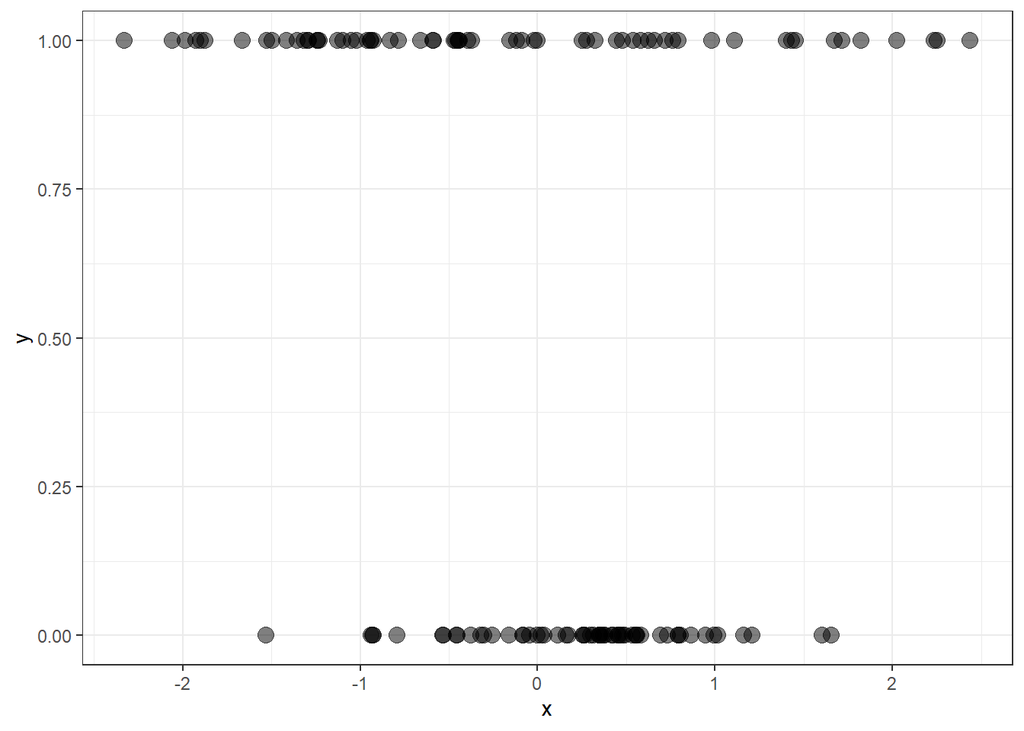

```r
model_pred_df %>%
  ggplot(mapping = aes(x = x, y = y)) +
  geom_point(size = 3.5, alpha = 0.5) +
  theme_bw()
```

### 1e)

The `model_pred_df` includes a column (variable) for a model predicted event probability.

**Use the `summary()` function to confirm that the lower an upper bounds on `pred_prob` are in fact between 0 and 1.**

#### SOLUTION

```r
model_pred_df %>% summary()
```

```
##        x               pred_prob       obs_class               y
##  Min.   :-2.329177   Min.   :0.2227   Length:125         Min.   :0.000
##  1st Qu.:-0.784695   1st Qu.:0.2323   Class :character   1st Qu.:0.000
##  Median : 0.114752   Median :0.3218   Mode  :character   Median :1.000
##  Mean   :-0.003672   Mean   :0.4547                      Mean   :0.528
##  3rd Qu.: 0.582418   3rd Qu.:0.6859                      3rd Qu.:1.000
##  Max.   : 2.438859   Max.   :0.9988                      Max.   :1.000
```

Although not required, you could use `dplyr::select()` to isolate the `pred_prob` variable from the other variables in the data set.

```r
model_pred_df %>%
  select(pred_prob) %>%
  summary()
```

```
##    pred_prob
##  Min.   :0.2227
##  1st Qu.:0.2323
##  Median :0.3218
##  Mean   :0.4547
##  3rd Qu.:0.6859
##  Max.   :0.9988
```

Either way, we see that `pred_prob` is indeed between 0 and 1. The minimum is about 22% while the maximum is close to the upper bound of 1.

### 1f)

With the binary outcome encoded as 0/1 within the `y` variable we can overlay the model predicted probability on top of the observed binary response.

**Use a `geom_line()` to plot the predicted event probability, `pred_prob`, with respect to the input `x`. Set the line `color` to be `"red"` within the `geom_line()` call. Overlay the binary response with the encoded response `y` as a scatter plot with `geom_point()`. Use the same marker size and transparency that you used for Problem 1d).**

#### SOLUTION

The figure below overlays the observed encoded binary response, `y`, and the model predicted probability, `pred_prob`. The predicted probability looks similar to a parabola with a minimum value near $x = 0.5$.

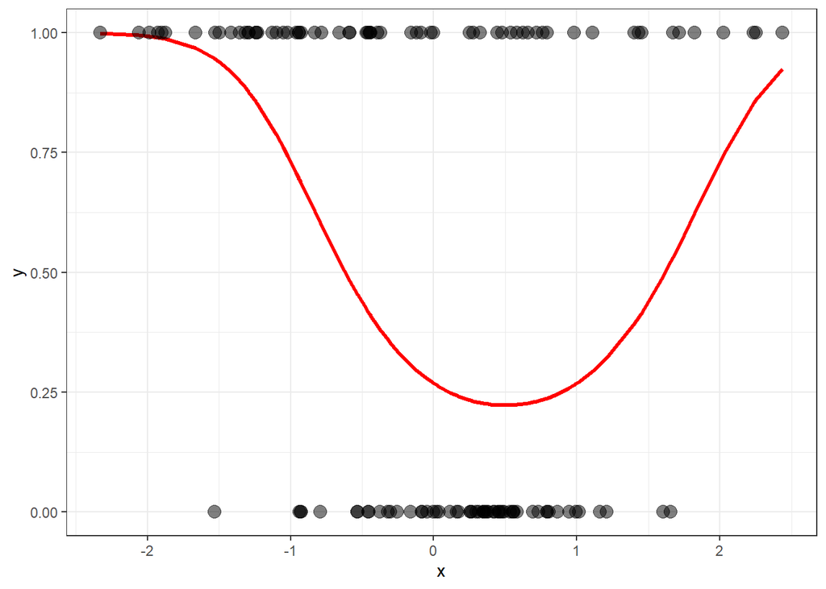

```r
model_pred_df %>%
  ggplot(mapping = aes(x = x, y = y)) +
  geom_line(mapping = aes(y = pred_prob),
            color = "red", size = 1.15) +
  geom_point(size = 3.5, alpha = 0.5) +
  theme_bw()
```

### 1g)

**Does the observed binary response “follow” the model predicted probability?**

## Problem 02

As you can see from the `model_pred_df` tibble, we have a model predicted probability but we do not have a corresponding classification.

### 2a)

In order to classify our predictions we must compare the predicted probability against a threshold. You will use `ifelse()` combined with `mutate()` to create a new variable `pred_class`. If the predicted probability, `pred_prob`, is greater than the threshold set the predicted class equal to `"event"`. If the predicted probability, `pred_prob`, is less than the threshold set the predicted class equal to the `"non_event"`.

**Use a threshold value of 0.5 and create the new variable `pred_class` such that the classification is `"event"` if the predicted probability is greater than the threshold and `"non_event"` if the predicted probability is less than the threshold. Assign the result to the new object `model_class_0.5`.**

#### SOLUTION

```r
model_class_0.5 <- model_pred_df %>%
  mutate(pred_class = ifelse(pred_prob > 0.5, "event", "non_event"))
```

### 2b)

You should now have a tibble that has a model classification and the observed binary outcome.

**Calculate the Accuracy, the fraction of observations where the model classification is correct.**

#### SOLUTION

There are multiple ways to accomplish this. One approach is to pipe the `model_class_0.5` object into the `summarize()` call directly and calculate the fraction of rows where `pred_class == obs_class` using the `mean()` function.

```r
model_class_0.5 %>%
  summarize(mean(pred_class == obs_class))
```

```
## # A tibble: 1 × 1
##   `mean(pred_class == obs_class)`
##                             <dbl>
## 1                           0.704
```

Alternatively, you could first create a new column which the result of the conditional statement, `pred_class == obs_class`. As an example, the code chunk below creates the `correct_class` variable which has shown by the result of the summary function is a logical (Boolean) consisting of either `TRUE` or `FALSE`.

*NOTE*: The `dplyr::select()` helper function `ends_with()` is used to select all variables (columns) with names that end with the provided phrase. This is a convenient way to quickly select variables that match a pattern. The helper functions `starts_with()`, `contains()`, and `matches()` all provide the ability to easily select variable names based on patterns.

```r
model_class_0.5 %>%
  mutate(correct_class = pred_class == obs_class) %>%
  select(ends_with("_class")) %>%
  summary()
```

```
##   obs_class          pred_class        correct_class
##  Length:125         Length:125         Mode :logical
##  Class :character   Class :character   FALSE:37
##  Mode  :character   Mode  :character   TRUE :88
```

Still another approach is to use the `ifelse()` function. The code chunk below uses `ifelse()` and then pipes the result to `summarize()` to show the same fraction of correctly classified rows as before.

```r
model_class_0.5 %>%
  mutate(correct_class = ifelse(pred_class == obs_class, "True", "False")) %>%
  summarise(mean(correct_class == "True"))
```

```
## # A tibble: 1 × 1
##   `mean(correct_class == "True")`
##                             <dbl>
## 1                           0.704
```

As stated already, there are multiple ways to perform this operation. Your approach might be different from the examples provided here, but the Accuracy value should be the same as what is given here.

### 2c)

We discussed in lecture how there are additional metrics we can consider with binary classification. Specifically, we can consider how a classification is correct, and how a classification is incorrect. A simple way to determine the counts per combination of `pred_class` and `obs_class` is with the `count()` function.

**Pipe `model_class_0.5` into `count()` with `pred_class` as the first argument and `obs_class` as the second argument. You should see 4 combinations and the number of rows in the data set associated with each combination (the number or count is given by the `n` variable).**

**How many observations are associated with False-Positives? How many observations are associated with True-Negatives?**

#### SOLUTION

```r
model_class_0.5 %>%
  count(pred_class, obs_class)
```

```
## # A tibble: 4 × 3
##   pred_class obs_class     n
##   <chr>      <chr>     <int>
## 1 event      event        35
## 2 event      non_event     6
## 3 non_event  event        31
## 4 non_event  non_event    53
```

A False Positive (FP) corresponds to predicting the `'event'` (the classic name of POSITIVE), but the event was not observed. The model was therefore incorrect (the classic name of FALSE). The False Positive row in the result from `count()` is therefore the `pred_class == 'event'` and `obs_class == 'non_event'` row. False Positives only occurred 6 times in the data set.

A True Negative (TN) corresponds to correctly predicting the event does not occur. Thus, the `pred_class` is `'non_event'` and the `obs_class` is also `'non_event'`. As we can see in the above print out, there are 53 TNs.

### 2d)

**You will now calculate the Sensitivity and False Positive Rate (FPR) associated with the model predicted classifications based on a threshold of 0.5. This question is left open ended. It is your choice as to how you calculate the Sensitivity and FPR. However, you CANNOT use an existing function from a library which performs the calculations automatically for you. You are permitted to use `dplyr` data manipulation functions. Include as many code chunks as you feel are necessary.**

#### SOLUTION

There are multiple ways to accomplish these steps. The code chunk below uses the `filter()` function to focus on the observations of `obs_class == 'event'`. The result is piped to `mutate()` in order to calculate the proportion associated with predicting the event and non-event. The result is piped into `filter()` to focus on correct classifications, and then the `pull()` function extracts the proportion and assigns the result to the variable `tpr_0.5`. The second code chunk below repeats those steps, but does so in order to calculate the FPR instead of the TPR. The FPR is assigned to the variable `fpr_0.5`.

```r
### calculate the TPR
tpr_0.5 <- model_class_0.5 %>%
  count(pred_class, obs_class) %>%
  filter(obs_class == "event") %>%
  mutate(prop_val = n / sum(n)) %>%
  filter(pred_class == "event") %>%
  pull(prop_val)
```

```r
### calculate the FPR
fpr_0.5 <- model_class_0.5 %>%
  count(pred_class, obs_class) %>%
  filter(obs_class == "non_event") %>%
  mutate(prop_val = n / sum(n)) %>%
  filter(pred_class == "event") %>%
  pull(prop_val)
```

As stated before, there are multiple ways to accomplish these actions. The above steps may not be the most efficient, but hopefully you can follow the workflow necessary to calculate the TPR and FPR. The correct values for this problem are displayed below.

```r
sprintf("Sensitivity or TPR at a threshold of 0.5: %1.2f", tpr_0.5)
```

```
## [1] "Sensitivity or TPR at a threshold of 0.5: 0.53"
```

```r
sprintf("FPR at a threshold of 0.5: %1.2f", fpr_0.5)
```

```
## [1] "FPR at a threshold of 0.5: 0.10"
```

### 2e)

We also discussed the ROC curve in addition to the confusion matrix. You will not have to calculate the ROC curve for a large number of threshold values. You will go through several calculations in order to demonstrate an understanding of the steps necessary to create an ROC curve.

The first action you must perform is to make classifications based on a different threshold compared to the default value of 0.5, which we used previously.

**Pipe the `model_pred_df` tibble into a `mutate()` function again, but this time determine the classifications based on a threshold value of 0.7 instead of 0.5. Assign the result to the object `model_class_0.7`.**

#### SOLUTION

```r
model_class_0.7 <- model_pred_df %>%
  mutate(pred_class = ifelse(pred_prob > 0.7, "event", "non_event"))
```

### 2f)

**Perform the same action as in Problem 2e), but this time for a threshold value of 0.3. Assign the result to the object `model_class_0.3`.**

#### SOLUTION

```r
model_class_0.3 <- model_pred_df %>%
  mutate(pred_class = ifelse(pred_prob > 0.3, "event", "non_event"))
```

## Problem 3

You will continue with the binary classification application in this problem.

### 3a)

**Calculate the Accuracy of the model classifications based on the 0.7 threshold. You CANNOT use an existing function that calculates Accuracy automatically for you. You are permitted to use `dplyr` data manipulation functions.**

#### SOLUTION

The `model_class_0.7` object is piped directly to the `summarise()` function in the code chunk below. The Accuracy is calculated using the `mean()` function based on `pred_class == obs_class`. The `mean()` function result is assigned to the `Accuracy` variable within the `summarise()` call. We see the displayed result as `Accuracy` instead of `mean(pred_class == obs_class)`.

```r
model_class_0.7 %>%
  summarise(Accuracy = mean(pred_class == obs_class))
```

```
## # A tibble: 1 × 1
##   Accuracy
##      <dbl>
## 1    0.672
```

### 3b)

**Calculate the Sensitivity and Specificity of the model classifications based on the 0.7 threshold. Again you can calculate these however you wish. Except you cannot use a model function library that performs the calculations automatically for you.**

#### SOLUTION

```r
tpr_0.7 <- model_class_0.7 %>%
  count(pred_class, obs_class) %>%
  filter(obs_class == "event") %>%
  mutate(prop_val = n / sum(n)) %>%
  filter(pred_class == "event") %>%
  pull(prop_val)

fpr_0.7 <- model_class_0.7 %>%
  count(pred_class, obs_class) %>%
  filter(obs_class == "non_event") %>%
  mutate(prop_val = n / sum(n)) %>%
  filter(pred_class == "event") %>%
  pull(prop_val)
```

The Sensitivity and FPR when the threshold is 0.7 are displayed below.

```r
sprintf("The TPR at a threshold of 0.7: %1.2f", tpr_0.7)
```

```
## [1] "The TPR at a threshold of 0.7: 0.39"
```

```r
sprintf("The FPR at a threshold of 0.7: %1.2f", fpr_0.7)
```

```
## [1] "The FPR at a threshold of 0.7: 0.02"
```

### 3c)

**Calculate the Accuracy of the model classifications based on the 0.3 threshold.**

#### SOLUTION

The `summarise()` function is used with `mean()` to calculate Accuracy as was done before.

```r
model_class_0.3 %>%
  summarise(Accuracy = mean(pred_class == obs_class))
```

```
## # A tibble: 1 × 1
##   Accuracy
##      <dbl>
## 1    0.712
```

### 3d)

**Calculate the Sensitivity and Specificity of the model classifications based on the 0.3 threshold. Again you can calculate these however you wish. Except you cannot use a model function library that performs the calculations automatically for you.**

#### SOLUTION

The `tpr_0.3` and `fpr_0.3` are assigned in the code chunk below using the same operations described earlier.

```r
tpr_0.3 <- model_class_0.3 %>%
  count(pred_class, obs_class) %>%
  filter(obs_class == "event") %>%
  mutate(prop_val = n / sum(n)) %>%
  filter(pred_class == "event") %>%
  pull(prop_val)

fpr_0.3 <- model_class_0.3 %>%
  count(pred_class, obs_class) %>%
  filter(obs_class == "non_event") %>%
  mutate(prop_val = n / sum(n)) %>%
  filter(pred_class == "event") %>%
  pull(prop_val)
```

The Sensitivity and FPR when the threshold is 0.3 are displayed below.

```r
sprintf("The TPR at a threshold of 0.3: %1.2f", tpr_0.3)
```

```
## [1] "The TPR at a threshold of 0.3: 0.73"
```

```r
sprintf("The FPR at a threshold of 0.3: %1.2f", fpr_0.3)
```

```
## [1] "The FPR at a threshold of 0.3: 0.31"
```

### 3e)

You have calculated the Sensitivity and FPR at three different threshold values. You will plot your simple 3 point ROC curve and include a “45-degree” line as reference.

**Use `ggplot2` to plot your simple 3 point ROC curve. You must compile the necessary values into a data.frame or tibble. You must use `geom_point()` to show the markers, `geom_abline()` with `slope=1` and `intercept=0` to show the reference “45-degree” line. And you must use `coord_equal(xlim=c(0,1), ylim=c(0,1))` with your graphic. This way both axes are plotted between 0 and 1 and the axes are equal.**

#### SOLUTION

The ROC curve consisting of just 3 threshold values is displayed below. The `tpr_*` and `fpr_*` variables created in the previous answers are first compiled into a `tibble()`. Notice that the variable `threshold` is also included in the `tibble`. You did not have to do this, but it will help provide context to the results. The `tibble` is then piped into `ggplot()` with the `x` aesthetic mapped to `FPR` and the `y` aesthetic mapped to `TPR`. The 3 point ROC curve is displayed with a `geom_point()` geom and the `geom_abline()` geom displays the reference diagonal line. I do not connect the dots of the simple ROC curve below. If you did in your solutions that is ok.

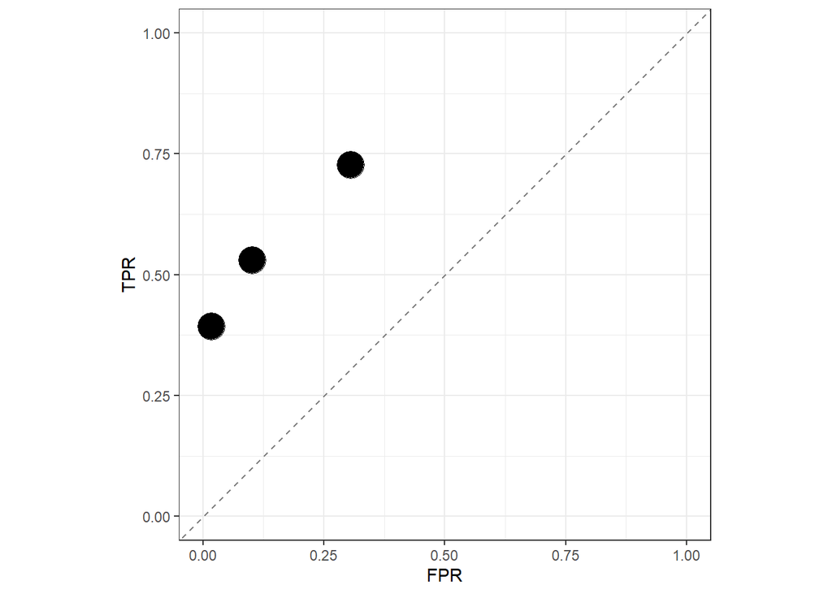

```r
tibble::tibble(
  threshold = c(0.3, 0.5, 0.7),
  TPR = c(tpr_0.3, tpr_0.5, tpr_0.7),
  FPR = c(fpr_0.3, fpr_0.5, fpr_0.7)
) %>%
  ggplot(mapping = aes(x = FPR, y = TPR)) +
  geom_point(size = 7.5) +
  geom_abline(slope = 1, intercept = 0, color = "grey50", linetype = "dashed") +
  coord_equal(xlim = c(0, 1), ylim = c(0, 1)) +
  theme_bw()
```

You are not required to do so, but you could use the `geom_text()` geom to include the threshold values associated with the 3 points. The code chunk below repeats the actions from the previous code chunk, but includes the `geom_text()` geom with the `label` aesthetic mapped to `threshold`. The text `size` was manually adjusted until the text was “contained” in the markers. This helps show that the TPR and FPR increase as the threshold decreases.

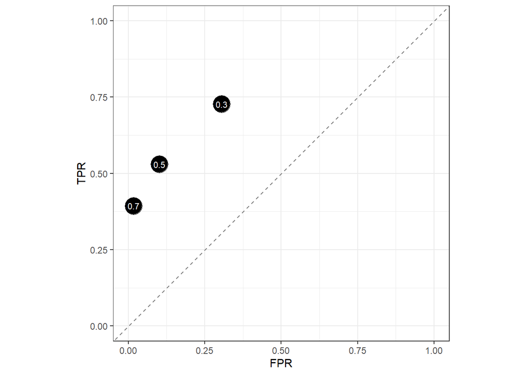

```r
tibble::tibble(
  threshold = c(0.3, 0.5, 0.7),
  TPR = c(tpr_0.3, tpr_0.5, tpr_0.7),
  FPR = c(fpr_0.3, fpr_0.5, fpr_0.7)
) %>%
  ggplot(mapping = aes(x = FPR, y = TPR)) +
  geom_point(size = 7.5) +
  geom_text(mapping = aes(label = threshold),
            color = "white", size = 2.85) +
  geom_abline(slope = 1, intercept = 0, color = "grey50", linetype = "dashed") +
  coord_equal(xlim = c(0, 1), ylim = c(0, 1)) +
  theme_bw()
```

As mentioned before, the steps taken to calculate the Sensitivity and FPR for each threshold value were not the most efficient. In fact, it’s quite tedious to have to repeat those actions multiple times. It would be more appropriate to define a function to calculate them for us! That way we do not resort to the error prone task of copying and pasting!

You were not required to use a function when you calculated the ROC curve. The code chunk below is provided if you would like to learn more about programming the “tidy” way. A function, `calc_confusion_metrics()`, is defined which consists of 2 input arguments. The first, `threshold`, is a threshold value, and the second, `df`, is a data set. The data set is assumed to have a column named `pred_class` and `obs_class` with the event of interest labeled `'event'` and the non-event labeled as `'non_event'`. After counting the combinations of `pred_class` and `obs_class`, the `calc_confusion_metrics()` function changes the names and labels to be consistent with the more general confusion matrix terms, `'T'`, `'F'`, `'P'`, and `'N'`. Several data reshaping steps are performed (the `right_join()` and `tidyr::spread()` function calls) in order to make sure all four confusion matrix cells are present. This is done because as we saw in lecture if the threshold is very low the classifications would never result in a False-Negative or True-Negative. The last step in the work flow is to calculate the different performance metrics associated with the confusion matrix that we discussed in lecture.

```r
calc_confusion_metrics <- function(threshold, df)
{
  df %>%
    mutate(pred_class = ifelse(pred_prob > threshold, "event", "non_event")) %>%
    count(obs_class, pred_class) %>%
    # rename to more general confusion matrix terms
    mutate(pred_class_name = ifelse(pred_class == "event", "P", "N"),
           pred_correct = ifelse(pred_class == obs_class, "T", "F")) %>%
    tidyr::unite(confusion_cell,
                 c("pred_correct", "pred_class_name"),
                 sep = "",
                 remove = FALSE) %>%
    select(n, confusion_cell) %>%
    # check all 4 confusion cells are there
    right_join(tibble::tibble(confusion_cell = c("TP", "FN", "FP", "TN"),
                              confusion_name = c("True-Positive",
                                                 "False-Negative",
                                                 "False-Positive",
                                                 "True-Negative")),
               by = "confusion_cell") %>%
    mutate(n = ifelse(is.na(n), 0, n)) %>%
    mutate(threshold = threshold) %>%
    select(-confusion_name) %>%
    tidyr::spread(confusion_cell, n) %>%
    # calculate metrics
    mutate(Accuracy = (TN + TP) / (TN + TP + FN + FP),
           Sensitivity = TP / (TP + FN),
           Specificity = TN / (FP + TN),
           FPR = 1 - Specificity)
}
```

The `calc_confusion_metrics()` function has `threshold` as the first argument to enable functionally looping over different threshold values using the `purrr` library. We will learn more about `purrr` as we progress through the semester, but I prefer `purrr` to defining for-loops. The code chunk below uses `purrr::map_dfr()` to loop over the three threshold values of interest (0.3, 0.5, 0.7) and assemble the result into a data.frame (tibble). The result is piped into `ggplot()` where the simple 3 point ROC curve is created as before.

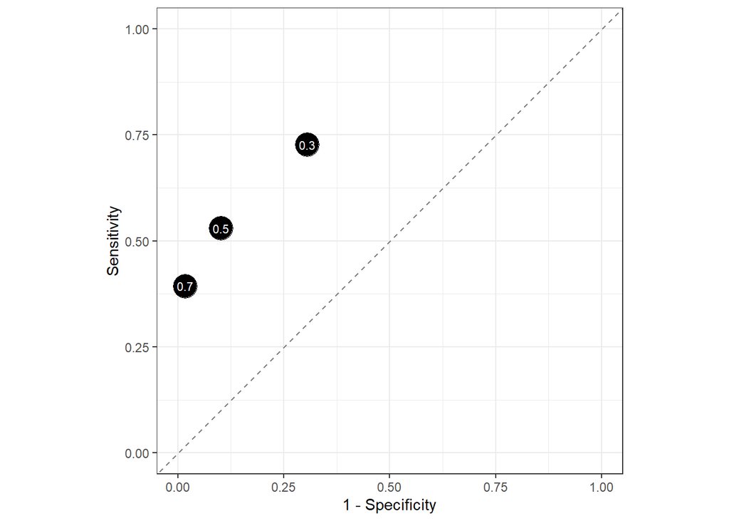

```r
purrr::map_dfr(c(0.3, 0.5, 0.7),
               calc_confusion_metrics,
               df = model_pred_df) %>%
  ggplot(mapping = aes(x = 1 - Specificity,
                       y = Sensitivity)) +
  geom_point(size = 7.5) +
  geom_text(mapping = aes(label = threshold), color = "white",
            size = 2.85) +
  geom_abline(slope = 1, intercept = 0, color = "grey50", linetype = "dashed") +
  coord_equal(xlim = c(0, 1), ylim = c(0, 1)) +
  theme_bw()
```

Setting up the function takes a little more work up front. However, it allows us to quickly expand beyond just 3 points on our ROC curve. You were **NOT** required to do this in your solutions, but to show what a more complete ROC curve looks like, the code chunk below calculates the TPR and FPR between thresholds of 0.2 and 0.8 in increments of 0.05.

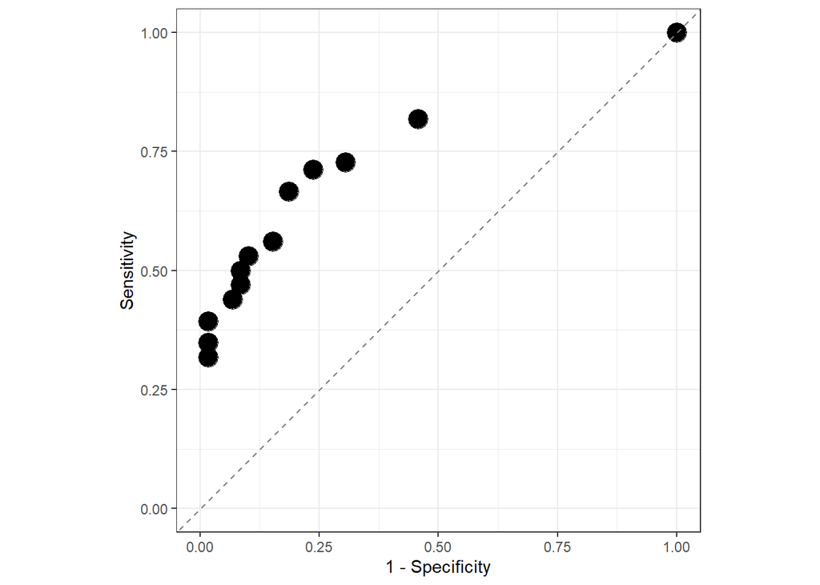

```r
purrr::map_dfr(seq(0.2, 0.8, by = 0.05),
               calc_confusion_metrics,
               df = model_pred_df) %>%
  ggplot(mapping = aes(x = 1 - Specificity,
                       y = Sensitivity)) +
  geom_point(size = 5.5) +
  geom_abline(slope = 1, intercept = 0, color = "grey50", linetype = "dashed") +
  coord_equal(xlim = c(0, 1), ylim = c(0, 1)) +
  theme_bw()
```

## Problem 04

You have practiced calculating several important binary classification performance metrics. Let’s use those metrics in a more realistic application to compare multiple models. The code chunk below reads in data that you will use for model training. The data consists of 4 inputs, `x1` through `x4`, and a binary outcome, `y`. The binary outcome is converted to a factor for you with the appropriate level order for modeling with `caret`.

```r
train_data_path <- 'hw03_train_data.csv'

df <- readr::read_csv(train_data_path, col_names = TRUE)
df <- df %>%
  mutate(y = factor(y, levels = c("event", "non_event")))
```

A glimpse of the data are provided to you below.

```r
df %>% glimpse()
```

```
## Rows: 155
## Columns: 5
## $ x1 <dbl> -0.3260365, 0.5524619, -0.6749438, 0.2143595, 0.3107692, 1.1739663,…
## $ x2 <dbl> -2.823000119, 0.462973827, 2.132869726, -0.270486687, 0.248525349, …
## $ x3 <dbl> 0.23917695, -0.50232861, -1.70387658, 0.52377224, 1.56417215, -2.46…
## $ x4 <dbl> -1.14362001, -0.30082496, -1.38891427, -2.02747975, 0.50521591, 0.7…
## $ y  <fct> event, event, event, non_event, event, non_event, event, non_event,…
```

### 4a)

**Are the levels of the binary outcome, `y`, balanced?**

#### SOLUTION

We can check if the binary outcome is balanced several ways. First, we can display the counts per level (unique value) with the `dplyr::count()` function.

```r
df %>% count(y)
```

```
## # A tibble: 2 × 2
##   y             n
##   <fct>     <int>
## 1 event        75
## 2 non_event    80
```

As we see above, the counts are quite similar and thus the outcome is balanced. We can also calculate the proportion per level if we would prefer to look at the relative frequency of each level.

```r
df %>%
  count(y) %>%
  mutate(prop = n / sum(n))
```

```
## # A tibble: 2 × 3
##   y             n  prop
##   <fct>     <int> <dbl>
## 1 event        75 0.484
## 2 non_event    80 0.516
```

We could also visualize the counts with a bar chart if we wanted to confirm visually that the outcome is balanced.

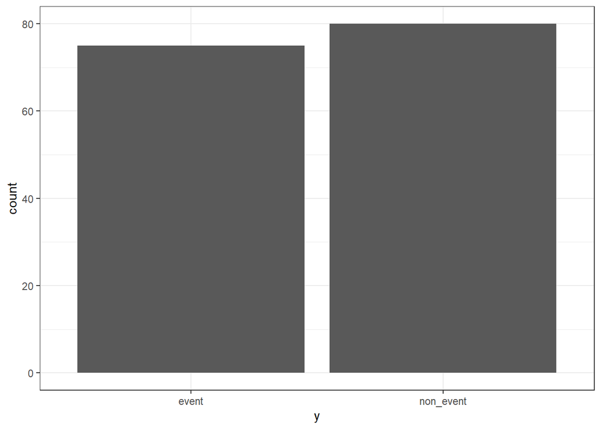

```r
df %>%
  ggplot(mapping = aes(x = y)) +
  geom_bar() +
  theme_bw()
```

Alternatively, we could `summarize()` the proportion of observations where `y` equals `'event'`.

```r
df %>%
  summarise(mean(y == 'event'))
```

```
## # A tibble: 1 × 1
##   `mean(y == "event")`
##                  <dbl>
## 1                0.484
```

Lastly, we could just use the `mean()` function with the conditional test `df$y == 'event'`.

```r
mean( df$y == 'event' )
```

```
## [1] 0.483871
```

The `mean()` function sums the number of rows that the `y` equals `'event'` and divides by the total number of observations. This is confirmed in the code chunk below.

```r
sum( df$y == 'event' ) / nrow(df)
```

```
## [1] 0.483871
```

Any of the above approaches demonstrate that the two levels of the binary outcome are nearly perfectly balanced.

### 4b)

Although it is best to explore the data in greater detail when we start a data analysis project, we will jump straight to modeling in this assignment.

Download and install `yardstick` if you have not done so already.

**Load in the `caret` package and the `yardstick` packages below. Use a separate code chunk for each package.**

#### SOLUTION

```r
library(caret)
library(yardstick)
```

### 4c)

Just as with regression problems, we must first specify the resampling scheme and primary performance metric when we use `caret` for classification problems. All students will use the same primary performance metric in this assignment. We will begin by focusing on the Accuracy. That said, you are free to decide the kind of resampling scheme you wish to use.

The resampling scheme is controlled by the `trainControl()` function, just as it was with regression problems. You must specify the arguments to the `trainControl()` function accordingly in this problem.

**Specify the resampling scheme you wish to use and assign the result to the `ctrl_acc` object. Specify the primary performance metric to be Accuracy by assigning `'Accuracy'` to the `metric_acc` argument.**

#### SOLUTION

You are free to decide what resampling you wish to use. The solutions use 10-fold cross-validation with 3-repeats.

```r
ctrl_acc <- trainControl(method = 'repeatedcv', number = 10, repeats = 3)

metric_acc <- "Accuracy"
```

### 4d)

You are going to train 8 binary classifiers in this problem. The different models will use different features derived from the 4 inputs. The 8 models must have the following features:

- model 1: linear additive features all inputs
- model 2: linear features and quadratic features all inputs
- model 3: linear features and quadratic features just inputs 1 and 2
- model 4: linear features and quadratic features just inputs 1 and 3
- model 5: linear features and quadratic features just inputs 1 and 4
- model 6: linear features and quadratic features just inputs 2 and 3
- model 7: linear features and quadratic features just inputs 2 and 4
- model 8: linear features and quadratic features just inputs 3 and 4

Model 1 is the conventional “linear method” for binary classification. All other models have linear and quadratic terms to allow capturing non-linear relationships with the event probability (just how that works will be discussed later in the semester). Model 2 creates the features from all four inputs. The remaining 6 models use the combinations of just two of the inputs. This scheme is trying to identify the best possible set of inputs to model the binary outcome in a step-wise like fashion. This is **not** an efficient way to identify the best set of features to use. Later in the semester, we will learn a much more efficient *modeling approach* that performs this operation for us!

**You must complete the 8 code chunks below. Use the formula interface to create the features in the model, analogous to the approach used in the previous assignment. You must specify the `method` argument in the `train()` function to be `"glm"`. You must specify the remaining arguments to `train()` accordingly.**

**The variable names and comments within the code chunks specify which model you are working with.**

*NOTE*: The models are trained in separate code chunks that way you can run each model separately from the others.

#### SOLUTION

We could type the formula for model 1 as `y ~ x1 + x2 + x3 + x4`. However, we can use the shortcut operator, `.`, to create all linear additive features because the data set, `df`, contains only inputs and the binary outcome. Thus, we can specify the formula as `y ~ .`. The short cut operator, `.`, will use all columns except the defined response (the variable to the left of the tilde) as linear features for the model. The short cut operator can streamline the amount we need to code. However, it is important to know how the features are used in a model. More advanced methods, such as tree-based methods, can use the short cut operator in the formula interface and still create non-linear and interaction features from those inputs. We will see how those kinds of models work later in the semester. For now, we can view the short cut operator as using all of the remaining variables in the data set as inputs to the model.

Model 1 is trained and assessed below using our desired resampling scheme. Although not required, the `preProcess` argument is specified such that the inputs are **standardized** before training each model. You were not required to do this for this assignment. The `preProcess` argument is included below to introduce how `caret` can pre-process the features to the model.

```r
### model 1
set.seed(2021)
mod_1_acc <- train(y ~ ., data = df,
                   method = 'glm',
                   metric = metric_acc,
                   preProcess = c("center", "scale"),
                   trControl = ctrl_acc)
```

You do not need to display the results, but it can be useful to see what the `caret` trained model object looks like. As we see below, each resample has about 140 training points. Thus, each resample has about 15 held-out test points. The Accuracy is calculated based on each resample’s 15 test points, and the Accuracy is averaged across all resamples (fold + repeats). The model with linear additive features has an averaged Accuracy of about 76%. Because the empirical proportion of the event is close to 50%, we can say this model is performing better than random guessing. However, we need to check the standard error on the averaged Accuracy to know for sure. The Kappa metric is also calculated and displayed below. Kappa can be useful when we have imbalanced data, and so we will describe Kappa in more detail later in the semester.

```r
mod_1_acc
```

```
## Generalized Linear Model
##
## 155 samples
##   4 predictor
##   2 classes: 'event', 'non_event'
##
## Pre-processing: centered (4), scaled (4)
## Resampling: Cross-Validated (10 fold, repeated 3 times)
## Summary of sample sizes: 140, 140, 139, 140, 139, 139, ...
## Resampling results:
##
##   Accuracy  Kappa
##   0.755     0.5084766
```

Next, let’s train the model with linear and quadratic features for each input. We will not use any kind of short cut operator or existing function to create these features. Instead, the features are manually typed in the formula interface below.

```r
### model 2
set.seed(2021)
mod_2_acc <- train(y ~ x1 + I(x1^2) + x2 + I(x2^2) + x3 + I(x3^2) + x4 + I(x4^2),
                   data = df,
                   method = 'glm',
                   metric = metric_acc,
                   preProcess = c("center", "scale"),
                   trControl = ctrl_acc)
```

The `caret` model object for the model with all linear and quadratic features is displayed below. If you pay close attention to the code in these code chunks, you will notice that the random seed is reset before each call to `train()`. This is critical when using `caret` to train multiple models on the same data. We want each model to use the same resample splits. Setting the seed before each call to `train()` makes sure that is indeed the case. If we do not set the seed the resample fold training sets and test sets will be different! We will therefore not compare the models on the exact same data. As we see below for the more complex model, the averaged Accuracy is higher than the previous simpler model. However, we cannot say for certain yet though if this more complex model is better. We need to consider the standard error on the average performance before we can make such a conclusion.

```r
mod_2_acc
```

```
## Generalized Linear Model
##
## 155 samples
##   4 predictor
##   2 classes: 'event', 'non_event'
##
## Pre-processing: centered (8), scaled (8)
## Resampling: Cross-Validated (10 fold, repeated 3 times)
## Summary of sample sizes: 140, 140, 139, 140, 139, 139, ...
## Resampling results:
##
##   Accuracy   Kappa
##   0.7818056  0.5618887
```

Next, let’s train the model that has linear and quadratic features derived from just the first two inputs. This model is a subset of the previous model. It will allow us to understand if we need all of the inputs or if we can use a simpler model can achieve a similar level of performance. Notice that the formula interface is similar to the previous code chunk, except only `x1` and `x2` are used.

```r
### model 3
set.seed(2021)
mod_3_acc <- train(y ~ x1 + I(x1^2) + x2 + I(x2^2),
                   data = df,
                   method = 'glm',
                   metric = metric_acc,
                   preProcess = c("center", "scale"),
                   trControl = ctrl_acc)
```

The model with linear and quadratic terms with just the first two inputs is shown below. The simpler model has an averaged Accuracy better than the previous more complex model!

```r
mod_3_acc
```

```
## Generalized Linear Model
##
## 155 samples
##   2 predictor
##   2 classes: 'event', 'non_event'
##
## Pre-processing: centered (4), scaled (4)
## Resampling: Cross-Validated (10 fold, repeated 3 times)
## Summary of sample sizes: 140, 140, 139, 140, 139, 139, ...
## Resampling results:
##
##   Accuracy   Kappa
##   0.8008333  0.5996106
```

Next, let’s go through and train the remaining models. We will assess their performance at the end once all models are trained.

```r
### model 4
set.seed(2021)
mod_4_acc <- train(y ~ x1 + I(x1^2) + x3 + I(x3^2),
                   data = df,
                   method = 'glm',
                   metric = metric_acc,
                   preProcess = c("center", "scale"),
                   trControl = ctrl_acc)
```

```r
### model 5
set.seed(2021)
mod_5_acc <- train(y ~ x1 + I(x1^2) + x4 + I(x4^2),
                   data = df,
                   method = 'glm',
                   metric = metric_acc,
                   preProcess = c("center", "scale"),
                   trControl = ctrl_acc)
```

```r
### model 6
set.seed(2021)
mod_6_acc <- train(y ~ x2 + I(x2^2) + x3 + I(x3^2),
                   data = df,
                   method = 'glm',
                   metric = metric_acc,
                   preProcess = c("center", "scale"),
                   trControl = ctrl_acc)
```

```r
### model 7
set.seed(2021)
mod_7_acc <- train(y ~ x2 + I(x2^2) + x4 + I(x4^2),
                   data = df,
                   method = 'glm',
                   metric = metric_acc,
                   preProcess = c("center", "scale"),
                   trControl = ctrl_acc)
```

```r
### model 8
set.seed(2021)
mod_8_acc <- train(y ~ x3 + I(x3^2) + x4 + I(x4^2),
                   data = df,
                   method = 'glm',
                   metric = metric_acc,
                   preProcess = c("center", "scale"),
                   trControl = ctrl_acc)
```

### 4e)

You will now compile all resample results together and compare the models based on their Accuracy.

**Complete the first code chunk below which assigns the models to the appropriate field within the `resamples()` function.**

**Then use the `summary()` function to summarize the Accuracy across the resamples and visualize the resample averaged performance with the `dotplot()` function from `caret`. In the function calls to both `summary()` and `dotplot()`, set the `metric` argument equal to `'Accuracy'`.**

**Which model is the best based on Accuracy? Are you confident it’s the best?**

*HINT*: The field names within the list contained in the `resamples()` call correspond to the model object you should use.

#### SOLUTION

The resampling results for all models are compiled together below.

```r
acc_results <- resamples(list(mod_1 = mod_1_acc,
                              mod_2 = mod_2_acc,
                              mod_3 = mod_3_acc,
                              mod_4 = mod_4_acc,
                              mod_5 = mod_5_acc,
                              mod_6 = mod_6_acc,
                              mod_7 = mod_7_acc,
                              mod_8 = mod_8_acc))
```

The `summary()` function gives summary statistics across all resamples. The overall min and max bounds of the Accuracy, as well as the the median and mean values, and the 0.25 and 0.75 quantiles are displayed. These overall summary statistics can help us understand the overall resample-to-resample variation for each model. However, we do not want to select the best model based on the overall max Accuracy. Instead we want to consider the averaged Accuracy across all resamples.

```r
summary(acc_results, metric = 'Accuracy')
```

```
##
## Call:
## summary.resamples(object = acc_results, metric = "Accuracy")
##
## Models: mod_1, mod_2, mod_3, mod_4, mod_5, mod_6, mod_7, mod_8
## Number of resamples: 30
##
## Accuracy
##         Min.   1st Qu.    Median      Mean   3rd Qu.      Max. NA's
## mod_1 0.5000 0.6718750 0.7333333 0.7550000 0.8531250 1.0000000    0
## mod_2 0.4375 0.7333333 0.8000000 0.7818056 0.8666667 0.9375000    0
## mod_3 0.5625 0.7333333 0.8125000 0.8008333 0.8729167 1.0000000    0
## mod_4 0.2500 0.5333333 0.6000000 0.6050000 0.6875000 0.8000000    0
## mod_5 0.4375 0.5333333 0.6000000 0.5918056 0.6666667 0.7500000    0
## mod_6 0.6000 0.7333333 0.7500000 0.7720833 0.8125000 0.9375000    0
## mod_7 0.6000 0.7333333 0.7750000 0.7681944 0.8125000 0.9333333    0
## mod_8 0.3750 0.5000000 0.5625000 0.5512500 0.6000000 0.7333333    0
```

As discussed in lecture, we do not want to look at the average *point estimate* in isolation. We want to consider the **uncertainty** on the average. The uncertainty on the average is represented in the figure below with the 95% confidence interval. Models with overlapping confidence intervals do not have statistically significant average performance values. As we see below `mod_3`, the model with linear and quadratic features of just the first two inputs (`x1` and `x2`) has the highest averaged Accuracy. The 95% confidence intervals overlap with model 2 which has linear and quadratic features associated with **all** inputs. Although we have overlap in the confidence intervals between the two models, `mod_3` is the simpler of the two! We would prefer to work with a simpler model with fewer features and thus `mod_3` would be selected as the best model.

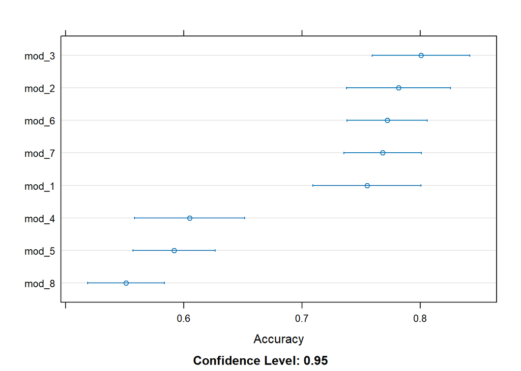

```r
dotplot(acc_results, metric = 'Accuracy')
```

The default plotting options for `dotplot()` show the 95% confidence interval. The figure above shows we only have separation (no overlap) on the average results between a group of models consisting of 3, 2, 6, 7, and 1 from another group of models including models 4, 5, and 8. The group with lower performance do **not** include input 2. The worst performing model, `mod_8`, does not include either input 1 or 2. Performance therefore gets worse when the first two inputs are not included! Thus, we can conclude that the first two inputs are important with input 2 being the most important.

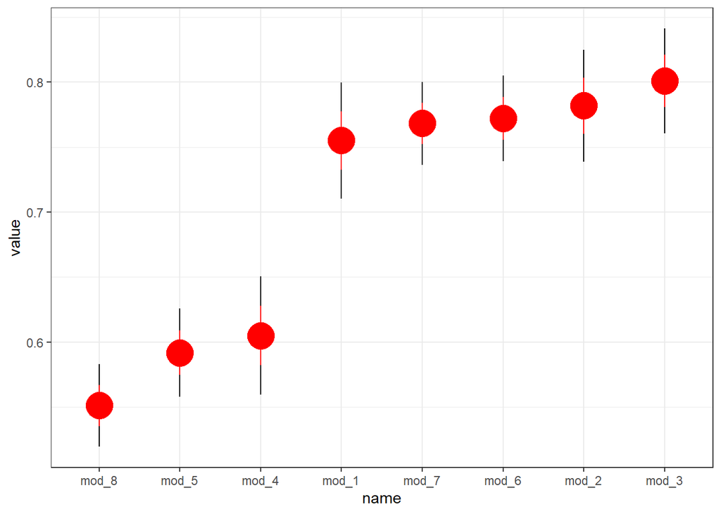

```r
as.data.frame(acc_results, method = 'Accuracy') %>%
  pivot_longer(!c("Resample")) %>%
  mutate(name = forcats::fct_reorder(name, value, mean)) %>%
  ggplot(mapping = aes(x = name, y = value)) +
  stat_summary(fun.data = 'mean_se',
               fun.args = list(mult = 2),
               size = 1.25) +
  stat_summary(fun.data = 'mean_se',
               fun.args = list(mult = 1),
               color = 'red',
               size = 2) +
  theme_bw()
```

### 4f)

Next, you will consider how a model was correct and how a model was wrong via the confusion matrix. You are allowed to use the `confusionMatrix()` function from the `caret` package in this assignment to create the confusion matrix. A `caret` model object can be passed as the argument to the `confusionMatrix()` function. The function will then calculate the average confusion matrix across all resample test-sets. The resulting confusion matrix is displayed with percentages instead of counts, as shown in the lecture slides. The interpretations however are the same.

**Use the `confusionMatrix()` function to display the confusion matrix for the top two and worst two models according to Accuracy.**

**How do the False-Positive and False-Negative behavior compare between these four models?**

#### SOLUTION

We saw previously that the two best models are `mod_3` and `mod_2` and the two worst models are `mod_5` and `mod_8`. The resampled average confusion matrices for the top performing model, `mod_3`, is given below. the resampled results are presented as percentages rather than counts (as described by the display statement). The resampled averaged Accuracy value is also displayed as reference. The best model has a higher percentage for False-Negatives than False-Positives.

```r
confusionMatrix(mod_3_acc)
```

```
## Cross-Validated (10 fold, repeated 3 times) Confusion Matrix
##
## (entries are percentual average cell counts across resamples)
##
##            Reference
## Prediction  event non_event
##   event      35.9       7.5
##   non_event  12.5      44.1
##
##  Accuracy (average) : 0.8
```

The confusion matrix for the second best model, `mod_2`, is shown below. The True-Positive and False-Negative performance are the same between the two. However, the second best model has a higher percentage of False-Positives compared with the best model. Thus, the second best model is classifying the event even though the event does not occur slightly more frequently than the best model.

```r
confusionMatrix(mod_2_acc)
```

```
## Cross-Validated (10 fold, repeated 3 times) Confusion Matrix
##
## (entries are percentual average cell counts across resamples)
##
##            Reference
## Prediction  event non_event
##   event      35.9       9.5
##   non_event  12.5      42.2
##
##  Accuracy (average) : 0.7806
```

The confusion matrix for the second worst model, `mod_5`, is shown below. We see that the averaged Accuracy is lower than the previous two models we looked at. Not surprisingly, the False-Positive and False-Negative percentages are higher for this model than either of the two better models. The False-Positive percentage is higher for this model compared with the False-Negative percentage meaning this model is “fooled” slightly easier when the event does not occur compared to when it occurs.

```r
confusionMatrix(mod_5_acc)
```

```
## Cross-Validated (10 fold, repeated 3 times) Confusion Matrix
##
## (entries are percentual average cell counts across resamples)
##
##            Reference
## Prediction  event non_event
##   event      28.6      21.1
##   non_event  19.8      30.5
##
##  Accuracy (average) : 0.5914
```

Lastly, the confusion matrix for the worst model, `mod_8`, is shown below. Although this model has a lower averaged Accuracy than the second worst model, the True-Negative percentage is higher than the second worst model! The False-Positive percentage is also lower! This means the worst model, according to Accuracy, out performs the second worst model at classifying the non-event when the event does not occur. However, The False-Negative percentage for the worst model is much higher than the second worst model. The worst model is therefore quite poor at classifying the event.

```r
confusionMatrix(mod_8_acc)
```

```
## Cross-Validated (10 fold, repeated 3 times) Confusion Matrix
##
## (entries are percentual average cell counts across resamples)
##
##            Reference
## Prediction  event non_event
##   event      20.6      17.2
##   non_event  27.7      34.4
##
##  Accuracy (average) : 0.5505
```

## Problem 05

Now that you have compared the models based on Accuracy, it is time to consider another performance metric. The Accuracy is calculated using a single threshold value. You will now examine the model performance across all possible thresholds by studying the ROC curve.

### 5a)

You will ultimately visually compare the ROC curves for the different models. Unfortunately with `caret`, we need to make several changes to the `trainControl()` function in order to support such comparisons. The code chunk below is started for you by including the necessary arguments you will need to visualize the ROC curves later.

**You must complete the code chunk by specifying the same resampling scheme you used in Problem 4c). You must also specify the primary performance metric as `'ROC'`. That is how `caret` knows it must calculate the Area Under the Curve (AUC) for the ROC curve.**

#### SOLUTION

```r
ctrl_roc <- trainControl(method = 'repeatedcv', number = 10, repeats = 3,
                         summaryFunction = twoClassSummary,
                         classProbs = TRUE,
                         savePredictions = TRUE)

metric_roc <- "ROC"
```

### 5b)

You will retrain the same set of 8 models that you trained in Problem 4d), but this time using the ROC AUC as the primary performance metric.

**Complete the code chunks below so that you train the 8 models again, but this time focusing on the ROC AUC. The object name and comments within the code chunks specify the model you should use.**

#### SOLUTION

```r
### model 1
set.seed(2021)
mod_1_roc <- train(y ~ ., data = df,
                   method = 'glm',
                   metric = metric_roc,
                   preProcess = c("center", "scale"),
                   trControl = ctrl_roc)
```

The `caret` trained object is displayed below. The performance metrics are different because we instructed `caret` to focus on the ROC curve. The `ROC` value is the Area Under the Curve (AUC) ROC curve. The `Sens` value is the Sensitivity (TPR) and the `Spec` value is the Specificity. Both the Sensitivity and Specificity displayed below are associated with a threshold of 0.5. The ROC curve displays the Sensitivity (TPR) and 1 - Specificity (FPR) as the threshold changes. Thus, the three metrics shown below are the area under that curve (which integrates across all threshold values) and a point on the ROC curve for a single threshold value.

```r
mod_1_roc
```

```
## Generalized Linear Model
##
## 155 samples
##   4 predictor
##   2 classes: 'event', 'non_event'
##
## Pre-processing: centered (4), scaled (4)
## Resampling: Cross-Validated (10 fold, repeated 3 times)
## Summary of sample sizes: 140, 140, 139, 140, 139, 139, ...
## Resampling results:
##
##   ROC        Sens       Spec
##   0.8050595  0.7416667  0.7666667
```

The other models are trained and assessed in the code chunks below. We will reserve describing the results after the training are all completed.

```r
### model 2
set.seed(2021)
mod_2_roc <- train(y ~ x1 + I(x1^2) + x2 + I(x2^2) + x3 + I(x3^2) + x4 + I(x4^2),
                   data = df,
                   method = 'glm',
                   metric = metric_roc,
                   preProcess = c("center", "scale"),
                   trControl = ctrl_roc)
```

```r
### model 3
set.seed(2021)
mod_3_roc <- train(y ~ x1 + I(x1^2) + x2 + I(x2^2),
                   data = df,
                   method = 'glm',
                   metric = metric_roc,
                   preProcess = c("center", "scale"),
                   trControl = ctrl_roc)
```

```r
### model 4
set.seed(2021)
mod_4_roc <- train(y ~ x1 + I(x1^2) + x3 + I(x3^2),
                   data = df,
                   method = 'glm',
                   metric = metric_roc,
                   preProcess = c("center", "scale"),
                   trControl = ctrl_roc)
```

```r
### model 5
set.seed(2021)
mod_5_roc <- train(y ~ x1 + I(x1^2) + x4 + I(x4^2),
                   data = df,
                   method = 'glm',
                   metric = metric_roc,
                   preProcess = c("center", "scale"),
                   trControl = ctrl_roc)
```

```r
### model 6
set.seed(2021)
mod_6_roc <- train(y ~ x2 + I(x2^2) + x3 + I(x3^2),
                   data = df,
                   method = 'glm',
                   metric = metric_roc,
                   preProcess = c("center", "scale"),
                   trControl = ctrl_roc)
```

```r
### model 7
set.seed(2021)
mod_7_roc <- train(y ~ x2 + I(x2^2) + x4 + I(x4^2),
                   data = df,
                   method = 'glm',
                   metric = metric_roc,
                   preProcess = c("center", "scale"),
                   trControl = ctrl_roc)
```

```r
### model 8
set.seed(2021)
mod_8_roc <- train(y ~ x3 + I(x3^2) + x4 + I(x4^2),
                   data = df,
                   method = 'glm',
                   metric = metric_roc,
                   preProcess = c("center", "scale"),
                   trControl = ctrl_roc)
```

### 5c)

You will now compile all resample results together and compare the models based on their area under the ROC curve.

**Complete the first code chunk below which assigns the models to the appropriate field within the `resamples()` function.**

**Then use the `summary()` function to summarize the ROC AUC across the resamples and visualize the resample averaged performance with the `dotplot()` function from `caret`. In the function calls to both `summary()` and `dotplot()`, set the `metric` argument equal to `'ROC'`.**

**Which model is the best based on ROC AUC? Are you confident it’s the best?**

*HINT*: The field names within the list contained in the `resamples()` call correspond to the model object you should use.

#### SOLUTION

All resample results for the models focusing on ROC AUC are compiled below.

```r
roc_results <- resamples(list(mod_1 = mod_1_roc,
                              mod_2 = mod_2_roc,
                              mod_3 = mod_3_roc,
                              mod_4 = mod_4_roc,
                              mod_5 = mod_5_roc,
                              mod_6 = mod_6_roc,
                              mod_7 = mod_7_roc,
                              mod_8 = mod_8_roc))
```

The `summary()` function summarizes the results across all resamples. Notice that there are a total of 30 resamples displayed below. This is because we used 10-fold cross-validation with 3-repeats. The maximum value of 1 is shown for several of the models. That value represents the ROC AUC in a single resample (fold+repeat). Even though a model may have a perfect ROC curve for an individual resample, there will be other resamples where the model will do worse. For example, `mod_1`, has a maximum ROC AUC of 1.0 and a minimum ROC AUC of about 0.55. Thus, even though `mod_1` has perfect performance in one resample, the ROC AUC in another resample is terrible! This again demonstrates that we should focus on the *average* performance and not the performance within a single training-test split!

```r
summary(roc_results, metric = 'ROC')
```

```
##
## Call:
## summary.resamples(object = roc_results, metric = "ROC")
##
## Models: mod_1, mod_2, mod_3, mod_4, mod_5, mod_6, mod_7, mod_8
## Number of resamples: 30
##
## ROC
##            Min.   1st Qu.    Median      Mean   3rd Qu.      Max. NA's
## mod_1 0.5535714 0.7220982 0.8002232 0.8050595 0.8867188 1.0000000    0
## mod_2 0.7031250 0.8750000 0.9107143 0.9074405 0.9821429 1.0000000    0
## mod_3 0.7343750 0.8911830 0.9285714 0.9191964 0.9821429 1.0000000    0
## mod_4 0.2031250 0.5468750 0.6584821 0.6369792 0.7410714 0.8571429    0
## mod_5 0.3437500 0.5937500 0.6417411 0.6310268 0.7114955 0.8281250    0
## mod_6 0.6562500 0.7539062 0.8671875 0.8444940 0.9464286 1.0000000    0
## mod_7 0.6607143 0.7544643 0.8515625 0.8453125 0.9107143 1.0000000    0
## mod_8 0.2187500 0.4481027 0.5502232 0.5409970 0.6367188 0.7678571    0
```

Let’s now visualize the resample averaged ROC AUC and the confidence interval on the estimate. As with our previous figure, we can use the confidence interval to assess which models are definitely better or worse than other based on if the confidence intervals overlap or not. The top two models based on ROC AUC and worst two performing models are the same as what we saw with Accuracy. However, the ROC AUC results yield a more clear distinction between the best performing model, `mod_3`, and the other models. Only `mod_2` the second best model has any overlap in the confidence intervals with `mod_3`.

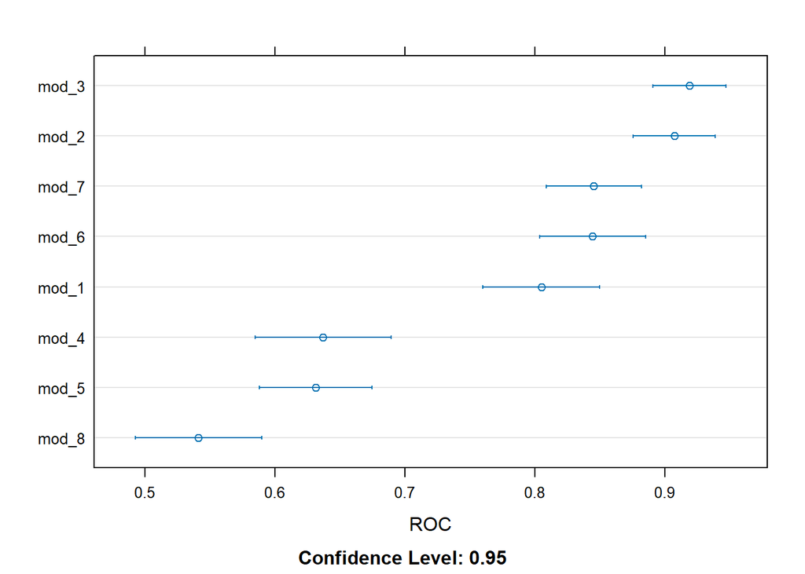

```r
dotplot(roc_results, metric = 'ROC')
```

### 5d)

By default, two other metrics are calculated by `caret` when we use the ROC AUC as the primary performance metric. Unlike ROC AUC, these two metrics are calculated with the default threshold. `caret` labels the the Sensitivity as the `Sens` metric and the Specificity as the `Spec` metric.

**Use the `summary()` and `dotplot()` functions again, but do not specify a metric. Just provide the `roc_results` as the input argument to the functions.**

**Which model has the highest True-Positive Rate at the default threshold? Which model has the lowest False-Positive Rate at the default threshold?**

#### SOLUTION

If we do not specify a metric with the `metric` argument, the `summary()` function returns the summaries for all three performance metrics: ROC AUC, Sensitivity, and Specificity.

```r
summary(roc_results)
```

```
##
## Call:
## summary.resamples(object = roc_results)
##
## Models: mod_1, mod_2, mod_3, mod_4, mod_5, mod_6, mod_7, mod_8
## Number of resamples: 30
##
## ROC
##            Min.   1st Qu.    Median      Mean   3rd Qu.      Max. NA's
## mod_1 0.5535714 0.7220982 0.8002232 0.8050595 0.8867188 1.0000000    0
## mod_2 0.7031250 0.8750000 0.9107143 0.9074405 0.9821429 1.0000000    0
## mod_3 0.7343750 0.8911830 0.9285714 0.9191964 0.9821429 1.0000000    0
## mod_4 0.2031250 0.5468750 0.6584821 0.6369792 0.7410714 0.8571429    0
## mod_5 0.3437500 0.5937500 0.6417411 0.6310268 0.7114955 0.8281250    0
## mod_6 0.6562500 0.7539062 0.8671875 0.8444940 0.9464286 1.0000000    0
## mod_7 0.6607143 0.7544643 0.8515625 0.8453125 0.9107143 1.0000000    0
## mod_8 0.2187500 0.4481027 0.5502232 0.5409970 0.6367188 0.7678571    0
##
## Sens
##            Min.   1st Qu.    Median      Mean   3rd Qu.      Max. NA's
## mod_1 0.2500000 0.5848214 0.7500000 0.7416667 0.8750000 1.0000000    0
## mod_2 0.2500000 0.6250000 0.7500000 0.7428571 0.8705357 1.0000000    0
## mod_3 0.2500000 0.6250000 0.7321429 0.7428571 0.8705357 1.0000000    0
## mod_4 0.2500000 0.5848214 0.7142857 0.6988095 0.8303571 1.0000000    0
## mod_5 0.2857143 0.5000000 0.5714286 0.5904762 0.7142857 1.0000000    0
## mod_6 0.3750000 0.5714286 0.7142857 0.6982143 0.8571429 1.0000000    0
## mod_7 0.2500000 0.5714286 0.7142857 0.6863095 0.8571429 1.0000000    0
## mod_8 0.0000000 0.3080357 0.4285714 0.4261905 0.5714286 0.7142857    0
##
## Spec
##        Min. 1st Qu. Median      Mean 3rd Qu.  Max. NA's
## mod_1 0.375 0.65625 0.7500 0.7666667 0.87500 1.000    0
## mod_2 0.500 0.75000 0.8750 0.8166667 0.96875 1.000    0
## mod_3 0.625 0.75000 0.8750 0.8541667 1.00000 1.000    0
## mod_4 0.250 0.37500 0.5000 0.5166667 0.62500 0.875    0
## mod_5 0.250 0.50000 0.6250 0.5916667 0.62500 0.875    0
## mod_6 0.500 0.75000 0.8750 0.8416667 1.00000 1.000    0
## mod_7 0.500 0.75000 0.8750 0.8458333 1.00000 1.000    0
## mod_8 0.250 0.62500 0.6875 0.6666667 0.75000 0.875    0
```

If we do not specify a `metric` value in `dotplot()`, all three performance metric resample averaged results are visualized. Interestingly, the Sensitivity and Specificity calculated at the default threshold of 0.5 do not show as clear separation between the models as ROC AUC does. This suggests that the difference in the behavior captured by ROC AUC is representative of the behavior as the threshold changes.

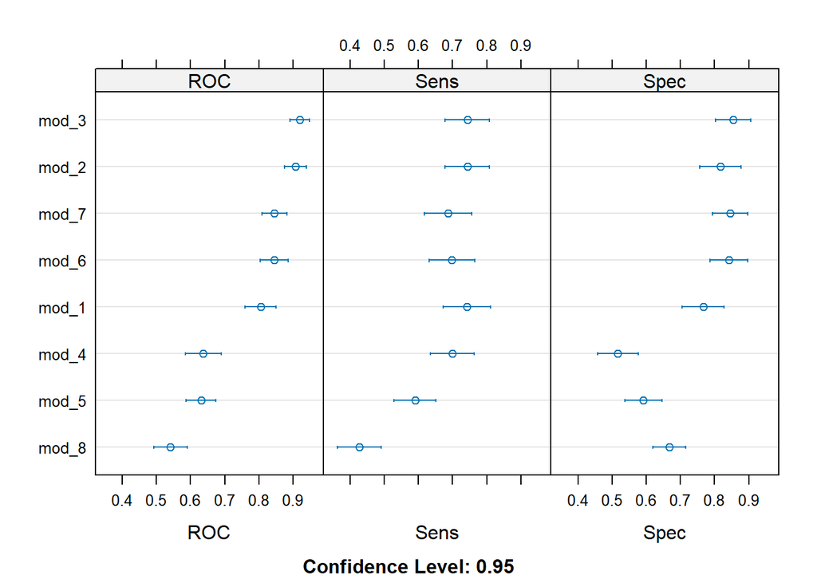

```r
dotplot(roc_results)
```

### 5e)

In order to visualize the ROC curve we need to understand how the resample hold-out test predictions are stored within the `caret` model objects. By default, hold-out test set predictions are not retained, in order to conserve memory. However, the `ctrl_roc` object set `savePredictions = TRUE` which overrides the default behavior and stores each resample test-set predictions.

The predictions are contained with the `$pred` field of the `caret` model object. The code chunk below displays the first few rows of the predictions for the `mod_1_roc` result for you. Note that the code chunk below is not evaluated by default. When you execute the code chunk below, you will see 7 columns. The column `obs` is the observed outcome and the column `event` is the predicted probability of the `event`. The `pred` column is the model classified outcome based on the default threshold of 50%. The `rowIndex` is the row from the original data set and serves to identify the row correctly. The `Resample` column tells us which resample fold the test point was associated with.

```r
mod_1_roc$pred %>% tibble::as_tibble()
```

```
## # A tibble: 465 × 7
##    pred      obs        event non_event rowIndex parameter Resample
##    <fct>     <fct>      <dbl>     <dbl>    <int> <chr>     <chr>
##  1 non_event non_event 0.352      0.648        6 none      Fold01.Rep1
##  2 event     event     0.540      0.460       16 none      Fold01.Rep1
##  3 non_event non_event 0.286      0.714       34 none      Fold01.Rep1
##  4 event     event     0.756      0.244       37 none      Fold01.Rep1
##  5 non_event non_event 0.411      0.589       45 none      Fold01.Rep1
##  6 event     event     0.735      0.265       53 none      Fold01.Rep1
##  7 non_event event     0.0231     0.977       88 none      Fold01.Rep1
##  8 non_event non_event 0.211      0.789       97 none      Fold01.Rep1
##  9 non_event event     0.0808     0.919      107 none      Fold01.Rep1
## 10 non_event event     0.483      0.517      117 none      Fold01.Rep1
## # ℹ 455 more rows
```

The ROC curve is calculated by comparing the model predicted probability to all possible thresholds to create many different classifications. Those different classifications are used to calculate many different confusion matrices. Thus, the columns of primary interest in the prediction object displayed above are the `obs` and `event` columns.

You manually created 3 points on the ROC curve previously in this assignment. Do NOT worry, you do NOT need to repeat those actions here! Instead you will use the `roc_curve()` function from the `yardstick` package to create the ROC curve data for you. The `roc_curve()` function has three primary arguments. The first is a data object which contains the predictions in a “tidy” format. The second is the name of the column that corresponds to the observed outcome (the truth or reference). The third is the name of the column in the data set that corresponds to the model predicted event probability.

**Pipe the prediction data object for the `mod_1_roc` `caret` object to the `roc_curve()`. The `obs` column is the observed outcome and the `event` column is the model predicted event probability. Display the result to the screen to confirm the `roc_curve()` function worked. If it did the first few rows should correspond to very low threshold values.**

**Why does the `sensitivity` have values at or near 1 when the `.threshold` is so low?**

#### SOLUTION

The resample hold-out test set predictions for `mod_1_roc` are pipped into the `roc_curve()` function below. The forward pipe operator, `%>%`, assigns the piped object as the first argument to the function. We then only need to specify the second and third arguments to `roc_curve()`. The second argument is the reference or observed outcome and the third argument is the model predicted probability of the event. Thus, the second argument is set to `obs` and the third argument is set to `event`. The portion of the ROC curve printed to screen shows us the `specificity` and `sensitivity` for very low thresholds. For example, the second row is a threshold of less than 0.005! With such a low threshold as long as the model predicts a probability greater than 0.5% the outcome will be classified as the event! The Sensitivity is very high because it is “easy” to classify the event with such a low threshold. The classification is always set to event which is why the True Positive Rate is 100%. However, we see that that Specificity (the True Negative Rate) is zero when the threshold is that low. This means the model is **always wrong** at classifying the non-event when the threshold is that low.

```r
mod_1_roc$pred %>% roc_curve(obs, event)
```

```
## # A tibble: 467 × 3
##    .threshold specificity sensitivity
##         <dbl>       <dbl>       <dbl>
##  1 -Inf           0             1
##  2    0.00354     0             1
##  3    0.00524     0             0.996
##  4    0.0142      0             0.991
##  5    0.0199      0             0.987
##  6    0.0221      0             0.982
##  7    0.0231      0             0.978
##  8    0.0234      0             0.973
##  9    0.0255      0             0.969
## 10    0.0280      0.00417       0.969
## # ℹ 457 more rows
```

### 5f)

You will now visualize the ROC curve associated with `mod_1_roc`.

**Repeat the same steps you performed in 5e) above, except pipe the result to the `autoplot()` method.**

#### SOLUTION

The ROC curve is plotted for us by piping the result of the `roc_curve()` to the `autoplot()` method. `autoplot()` is a function within the `ggplot2` package which creates a plot specific to an object. The attributes (or metadata) associated with the returned result of `roc_curve()` instruct `autoplot()` to create the ROC curve. We see the properties described in lecture where the Sensitivity (TPR) and the False Positive Rate (FPR) are both low at the bottom left hand corner of the plot. The lower left corner corresponds to very high thresholds. Conversely, the TPR and FPR are both high on the upper right hand corner of the plot which corresponds to very low thresholds. The specific curve shown below is between the ideal “right angle step change” and the 45-degree line of a bad model.

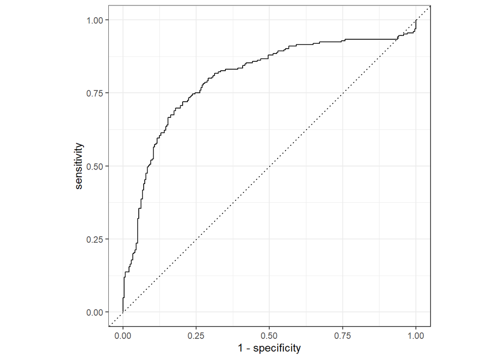

```r
mod_1_roc$pred %>%
  roc_curve(obs, event) %>%
  autoplot()
```

### 5g)

The ROC curve displayed in 5f) is the resample averaged ROC curve. You can examine the individual resample hold-out test set ROC curves by specifying a grouping structure with the `group_by()` function. This can help you get a sense of the variability in the ROC curve.

**Pipe the prediction object associated with `mod_1_roc` to the `group_by()` function where you specify the grouping variable to be `Resample`. Pipe the result to `roc_curve()` where you specify the same arguments as in the previous questions. Finally, pipe the result to `autoplot()`.**

#### SOLUTION

The code chunk below groups the `mod_1_roc$pred` results by `Resample` before calculating and plotting the ROC curve. The grouping operation allows the individual resample folds’ hold-out set ROC curves to be visualized. Your exact plot will depend on your resampling scheme. We no longer have a single smoothed curve. Instead the plot below shows 30 ROC curves because 10-fold cross-validation with 3-repeats was specified. Each curve looks like a stair-step because the ROC curve is calculated from about 15 points in each resample hold-out set. With such a small hold-out set the behavior is all over the place. Some resample fold hold-out sets have excellent performance, with ROC curves close to the ideal step change shape. However, we also have folds where the hold-out set performance is quite poor as represented by the ROC curve following the 45-degree line (shown by the small black dots in the figure). The figure below reveals that the model’s performance is quite variable and thus the ROC curve behavior is rather uncertain.

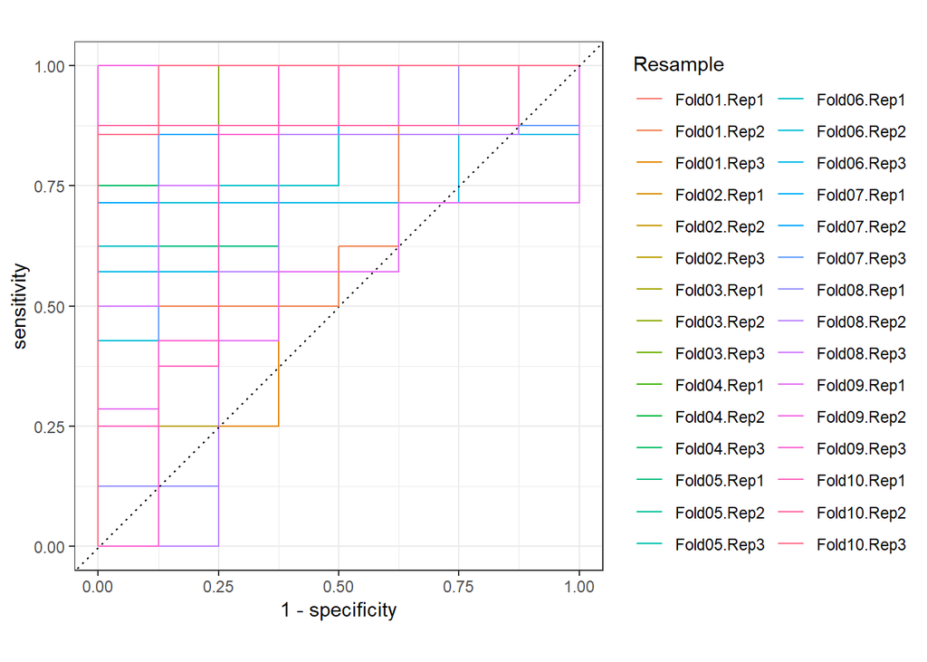

```r
mod_1_roc$pred %>%
  group_by(Resample) %>%
  roc_curve(obs, event) %>%
  autoplot()
```

The variability in the ROC curve behavior could be due to the relatively low hold-out set sample size. We can try to get some idea about that in these solutions because repeated cross-validation was used. We can examine the variability in the average behavior within each repeat. You were not required to do this for your submission, the previous graph was enough to receive full credit on this question. In order to group by the repeats and thus average over the folds within the repeat, we need to perform some data manipulation steps. The `Resample` column in `mod_1_roc$pred` stores resample cross-validation results as fold and repeat separated by a period, `.`. Thus, we need to separate the `Resample` column into a column with the fold ID and a column with the repeat ID. That data manipulation step is shown in the code chunk below via the `tidyr::separate()` function.

```r
mod_1_roc$pred %>%
  tidyr::separate(Resample,
                  c("fold_id", "repeat_id"),
                  sep = "\\.",
                  remove = FALSE) %>%
  select(Resample, fold_id, repeat_id) %>%
  head(10)
```

```
##       Resample fold_id repeat_id
## 1  Fold01.Rep1  Fold01      Rep1
## 2  Fold01.Rep1  Fold01      Rep1
## 3  Fold01.Rep1  Fold01      Rep1
## 4  Fold01.Rep1  Fold01      Rep1
## 5  Fold01.Rep1  Fold01      Rep1
## 6  Fold01.Rep1  Fold01      Rep1
## 7  Fold01.Rep1  Fold01      Rep1
## 8  Fold01.Rep1  Fold01      Rep1
## 9  Fold01.Rep1  Fold01      Rep1
## 10 Fold01.Rep1  Fold01      Rep1
```

We can now create the ROC curves grouped by the repeats and thus average over the folds within the repeat. The repeat averaged ROC curves are shown in the figure below. The three curves are relatively similar to each other. The averaged cross-validation behavior therefore seems relatively consistent, even if the fold-to-fold variability is quite high. The variation in the averaged cross-validation behavior can only be examined if repeated cross-validation is used to assess the model performance.

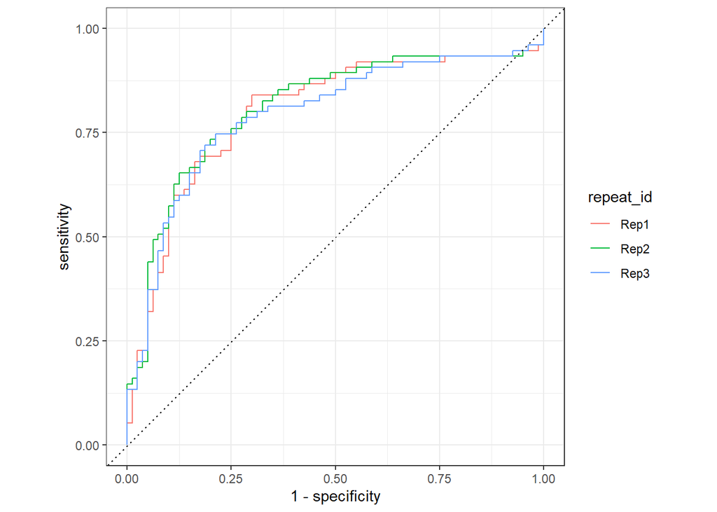

```r
mod_1_roc$pred %>%
  tidyr::separate(Resample,
                  c("fold_id", "repeat_id"),
                  sep = "\\.",
                  remove = FALSE) %>%
  group_by(repeat_id) %>%
  roc_curve(obs, event) %>%
  autoplot()
```

### 5h)

A function is defined for you in the code chunk below. This function compiles all model results together to enable comparing their ROC curves.

```r
compile_all_model_preds <- function(m1, m2, m3, m4, m5, m6, m7, m8)
{
  purrr::map2_dfr(list(m1, m2, m3, m4, m5, m6, m7, m8),
                  as.character(seq_along(list(m1, m2, m3, m4, m5, m6, m7, m8))),
                  function(ll, lm){
                    ll$pred %>% tibble::as_tibble() %>%
                      select(obs, event, Resample) %>%
                      mutate(model_name = lm)
                  })
}
```

The code chunk below is also completed for you. It passes the `caret` model objects with the saved predictions to the `compile_all_model_preds()` function. The result is printed for you below so you can see the column names. Notice there is a new column `model_name` which stores the name of the model associated with the resample hold-out test set predictions. By default the code chunk below is not executed.

```r
all_model_preds <- compile_all_model_preds(mod_1_roc, mod_2_roc, mod_3_roc,
                                           mod_4_roc, mod_5_roc,
                                           mod_6_roc, mod_7_roc, mod_8_roc)

all_model_preds
```

```
## # A tibble: 3,720 × 4
##    obs        event Resample    model_name
##    <fct>      <dbl> <chr>       <chr>
##  1 non_event 0.352  Fold01.Rep1 1
##  2 event     0.540  Fold01.Rep1 1
##  3 non_event 0.286  Fold01.Rep1 1
##  4 event     0.756  Fold01.Rep1 1
##  5 non_event 0.411  Fold01.Rep1 1
##  6 event     0.735  Fold01.Rep1 1
##  7 event     0.0231 Fold01.Rep1 1
##  8 non_event 0.211  Fold01.Rep1 1
##  9 event     0.0808 Fold01.Rep1 1
## 10 event     0.483  Fold01.Rep1 1
## # ℹ 3,710 more rows
```

You will now create a figure which displays the resample averaged ROC curve for each model.

**Pipe the `all_model_preds` object to `group_by()` and specify the grouping variable as `model_name`. Pipe the result to `roc_curve()` and specify the arguments accordingly. Pipe the result to `autoplot()` to generate the figure.**

**Which model is the best? Is the result consistent with the ROC AUC summary metrics you calculated previously? Which model is closest to a “completely ineffective model” and why is that so?**

#### SOLUTION

The resample averaged ROC curves are compared across all 8 models in the figure below. Model 8 is the worst with an averaged ROC curve that follows the 45-degree line and thus is not better than randomly guessing the outcome. All of these curves are based on hold-out test behavior and so it is appropriate to identify the best model as the one that is closest to the ideal shape. We can see that model 2 and 3 have the ROC curves closest to the ideal shape out of the 8 models. It is difficult to see which of the those two is the best, but model 3’s curve is slightly higher to the left than model 2. This is consistent with the ROC AUC summarized results with model 3’s resample averaged ROC AUC slightly better than model 2. The two models have overlapping confidence intervals which represents they have essentially the same performance.

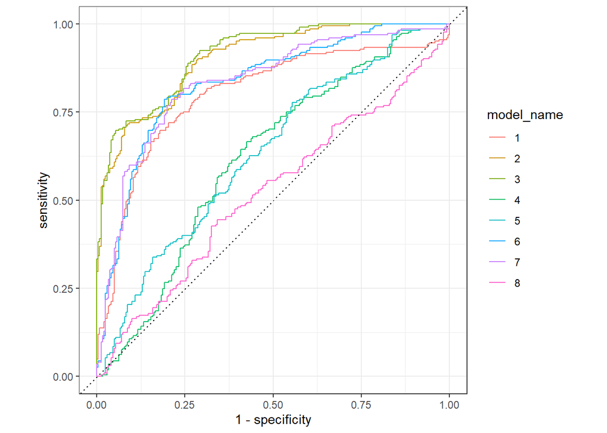

```r
all_model_preds %>%
  group_by(model_name) %>%
  roc_curve(obs, event) %>%
  autoplot()
```

## Problem 06

The performance metrics you have focused on up to this point are point-wise comparison metrics which evaluate the classification performance of a model. As discussed in lecture, binary classifier performance can also be measured based on the **calibration** between the predicted probability and the observed event proportion. The performance is represented graphically via the **calibration curve** which visualizes the correlation between the model predictions and the observed proportion of the event.

Regardless of your rankings in the previous questions, you will compare the performance of model 1, model 3, and model 8 with the calibration curve. Although multiple functions exist to create the calibration curve, you **must** create the calibration curve manually in this problem. You are only allowed to use functions from the `dplyr` and `ggplot2` packages. You are **not** allowed to use any third party function to calculate the calibration curve in this problem.

In the two previous problems, you used resampling to assess model performance. We could create the calibration curve based on the resample fold test sets, but we will instead start simpler and use a dedicated hold-out set that is different from the training data. The hold-out set is read in for you in the code chunk below.

```r
test_data_path <- 'hw03_test_data.csv'

df_test <- readr::read_csv(test_data_path, col_names = TRUE)
df_test <- df_test %>%
  mutate(y = factor(y, levels = c("event", "non_event")))
```

The code chunk below shows a glimpse of the test set, which demonstrates the test set has the same column names as the training set.

```r
df_test %>% glimpse()
```

```
## Rows: 120
## Columns: 5
## $ x1 <dbl> -0.226126900, 1.573924144, -1.054455037, 0.083051357, 0.424592933, …
## $ x2 <dbl> -0.3361453, 0.5445463, 0.5837157, -0.8979020, -0.6339053, -0.641050…
## $ x3 <dbl> -1.22092445, -0.41352769, 2.45375479, -0.31070519, 0.40871874, 0.15…
## $ x4 <dbl> 0.59734091, 1.16494692, 0.41455929, 0.03209814, -0.91177742, 0.1022…
## $ y  <fct> event, non_event, non_event, non_event, non_event, non_event, non_e…
```

### 6a)

The first step to create the calibration curve requires making predictions. The `predict()` function for a `caret` trained object function has two main arguments. The first is the model object we will use to make predictions with and the second, `newdata`, is the data set to predict. The input columns must have the same names as the inputs to the training data that trained the model.

By default, a binary classifier will return the classifications assuming a 50% threshold. As discussed in lecture, the calibration curve does not work with classifications. Instead we need the predicted probability! We can override the default prediction behavior by setting additional arguments to the `predict()` function. Specifically, the `type` argument instructs the model to return a “type” of prediction. We want the predicted probability and so you must set `type = 'prob'` in the `predict()` function call.

**Predict the hold-out test set using model 1 and assign the result to the variable `pred_test_1`. Return the predicted probability by setting the `type` argument to `'prob'`.**

**Print the data type of the `pred_test_1` object to the screen and use the `head()` function to display the “top” of the object.**

*HINT*: It does not matter whether you use the model 1 assessed based on Accuracy or ROC in this problem.

#### SOLUTION

The prediction result is created in the code chunk below.

```r
pred_test_1 <- predict(mod_1_acc, newdata = df_test, type = 'prob')
```

The object is a data.frame as confirmed using the `class()` function in the code chunk below.

```r
pred_test_1 %>% class()
```

```
## [1] "data.frame"
```

The top few rows shown by the `head()` function reveal there are two columns.

```r
pred_test_1 %>% head()
```

```
##       event non_event
## 1 0.2607671 0.7392329
## 2 0.7113031 0.2886969
## 3 0.7467320 0.2532680
## 4 0.1964256 0.8035744
## 5 0.3579798 0.6420202
## 6 0.2867937 0.7132063
```

The problem statement said it did not matter if you used the `mod_1_roc` or the `mod_1_acc` model objects when you made the predictions. Let’s confirm that is indeed the case. You did not have to do this for the assignment.

```r
all.equal(pred_test_1,
          predict(mod_1_roc, newdata = df_test, type = 'prob'))
```

```
## [1] TRUE
```

Later in the semester, we will learn why these two objects produce the same predictions. We will also learn how other model types may not give the same predictions when we *tune* to maximize for Accuracy compared to ROC AUC.

### 6b)

Your `pred_test_1` object should have 2 columns. The `event` column gives the predicted probability that `y == 'event'` and the `non_event` column stores the predicted probability that `y == 'non_event'`.

**What is the relationship between the values in the `event` column and the `non_event` column?**

#### SOLUTION

The `event` columns stores the probability of the event and the `non_event` column stores the probability of the non-event. The outcome is binary and thus those are the only two values associated with the outcome. The outcome must equal one of those two values and thus the sum of the event probability and the non-event probability equals 1.

You were not required to do this, but it’s straightforward to show that is indeed true. Let’s use `mutate()` to add a column to the `pred_test_1` dataframe which is equal to the sum of the two columns. The code chunk below shows the first few rows of the mutated dataframe with `head()`. As we can see below, the `sum_probs` column is equal to 1!

```r
pred_test_1 %>%
  mutate(sum_probs = event + non_event) %>%
  head()
```

```
##       event non_event sum_probs
## 1 0.2607671 0.7392329         1
## 2 0.7113031 0.2886969         1
## 3 0.7467320 0.2532680         1
## 4 0.1964256 0.8035744         1
## 5 0.3579798 0.6420202         1
## 6 0.2867937 0.7132063         1
```

To fully show that the sum of `event` and `non_event` is always 1, the code chunk below uses the `count()` function to count the number of rows associated with each unique value of `sum_probs`. As we can see below, there is only 1 value!

```r
pred_test_1 %>%
  mutate(sum_probs = event + non_event) %>%
  count(sum_probs)
```

```
##   sum_probs   n
## 1         1 120
```

### 6c)

The code chunk below binds the columns in `pred_test_1` with the `df_test` dataframe to create a new dataframe which includes the predicted probability of the event and the observed output, `y`, for the hold-out test set. **PLEASE NOTE**: the code chunk below is **NOT** evaluated by default. You must change the `eval` chunk option to make sure the code chunk is executed when you render the report.

```r
test_df_1 <- df_test %>% bind_cols(pred_test_1)
```

As discussed in lecture, the calibration curve bins or lumps the predicted probability into uniformly spaced intervals. The empirical proportion of the event within each bin must be calculated. Thus, you need to convert the numeric predicted probability into a discrete or categorical variable.

A simple, yet effective, approach for categorizing a continuous variable is the `cut()` function. The cut function is demonstrated in the code chunk below. The variable `x` is a column within a tibble (a dataframe). The `x` variable consists of integers between 0 and 100. The `x` variable is “cut” or divided into bins with **break points** at values of 0, 10, 20, 30, etc. The break points are created using the `seq()` function from 0 to 100 *by* increments of 10. The tibble is piped to the `count()` function to count the number of rows associated with each unique value of the `x_bin`. Pay close attention to the displayed values of `x_bin`. The values of `x_bin` show the “cut” or “divided” intervals.

```r
tibble::tibble(x = 0:100) %>%
  mutate(x_bins = cut(x,
                      breaks = seq(0, 100, by = 10),
                      include.lowest = TRUE)) %>%
  count(x_bins)
```

```
## # A tibble: 10 × 2
##    x_bins       n
##    <fct>    <int>
##  1 [0,10]      11
##  2 (10,20]     10
##  3 (20,30]     10
##  4 (30,40]     10
##  5 (40,50]     10
##  6 (50,60]     10
##  7 (60,70]     10
##  8 (70,80]     10
##  9 (80,90]     10
## 10 (90,100]    10
```

You must use the `cut()` function to bin the predicted probability associated with model 1 into 10 bins. Think carefully about how to specify the `breaks` argument to `cut()` so that the probability is divided into 10 uniform intervals.

**Pipe `test_df_1` to `mutate()` and create a variable `pred_bin` by cutting the predicted probability into 10 uniform intervals. Assign the result to the `test_df_1_b` object.**

*HINT*: You should not pipe the result to `count()` as the previous code chunk did. The `count()` function was used to show the *levels* of the created discrete variable.

#### SOLUTION

In order to create 10 evenly spaced bins between 0 and 1, we need to set the `breaks` argument to `cut()` as a vector from 0 to 1 in increments of 0.1. The code chunk below shows how to create this vector with the `seq()` function.

```r
seq(0, 1, by = 0.1)
```

```
##  [1] 0.0 0.1 0.2 0.3 0.4 0.5 0.6 0.7 0.8 0.9 1.0
```

The `cut()` function is used in the code chunk below to categorize the predicted event probability. The `seq()` result demonstrated above is assigned to the `breaks` argument.

```r
test_df_1_b <- test_df_1 %>%
  mutate(pred_bin = cut(event,
                        breaks = seq(0, 1, by = 0.1),
                        include.lowest = TRUE))
```

### 6d)

**Use the `count()` function to count the number of rows associated with each unique value of `pred_bin` in the `test_df_1_b` object. Display the result to the screen. How many unique values are displayed?**

#### SOLUTION

```r
test_df_1_b %>% count(pred_bin)
```

```
## # A tibble: 10 × 2
##    pred_bin      n
##    <fct>     <int>
##  1 [0,0.1]      11
##  2 (0.1,0.2]    13
##  3 (0.2,0.3]    11
##  4 (0.3,0.4]     7
##  5 (0.4,0.5]    19
##  6 (0.5,0.6]    15
##  7 (0.6,0.7]    22
##  8 (0.7,0.8]    13
##  9 (0.8,0.9]     5
## 10 (0.9,1]       4
```

### 6e)

Show the counts per bin again but this time visualize the counts with a bar chart.

**Create a bar chart with `ggplot2` for the counts associated with unique value of `pred_bin`.**

#### SOLUTION

The previous problem displayed the counts per bin essentially as a table. Instead, of having to read the values, the bar chart will display the counts as the height of each bar. We also do not need to even use the `count()` function! The `ggplot2` `geom_bar()` function will execute the grouping and counting for us behind the scenes.

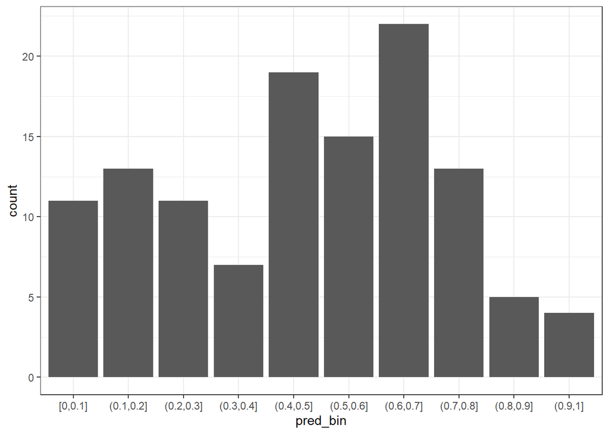

```r
test_df_1_b %>%
  ggplot(mapping = aes(x = pred_bin)) +
  geom_bar() +
  theme_bw()
```

### 6f)

As shown in the lecture slides, we can create a stacked bar chart to get a rough idea about the number of events and non-events within each predicted probability bin. This is simple to do with `ggplot2` by using the `fill` aesthetic associated with the `geom_bar()` geometric object.

**Create a stacked bar chart with `ggplot2` where the `fill` aesthetic is mapped to the observed binary outcome. Override the default fill color scheme by including the `scale_color_brewer()` function after the `geom_bar()` layer. Set the `palette` argument in `scale_color_brewer()` to `'Set1'`.**

**Do any bins consist of only events? Do any bins consist of only non-events?**

*HINT*: Which variable in the `test_df_1` tibble corresponds to the observed outcome?

#### SOLUTION

The `fill` argument to `geom_bar()` corresponds to performing a `group_by()` operation between two variables. We are thus counting the number of observations associated with the combination between those two variables. The different fill colors shown correspond to the combination of the x-aesthetic factor and the fill factor. The total height of the bar corresponds to the number of observations for the x-aesthetic, alone.

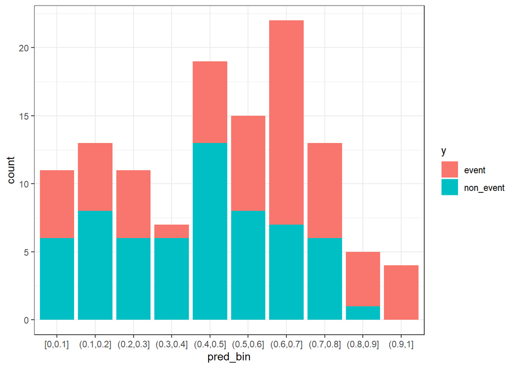

```r
test_df_1_b %>%
  ggplot(mapping = aes(x = pred_bin)) +
  geom_bar(mapping = aes(fill = y)) +
  theme_bw()
```

There was a typo in the original instructions. Changing the bar fill requires the `scale_fill_*` functions **not** `scale_color_*` function. The `fill` is the “color” applied to a region or area, while `color` is applied to a point or line. So you only needed to create the above figure to receive full credit.

The intended figure was to use the `scale_fill_brewer()` function to change the color palette, as shown below.

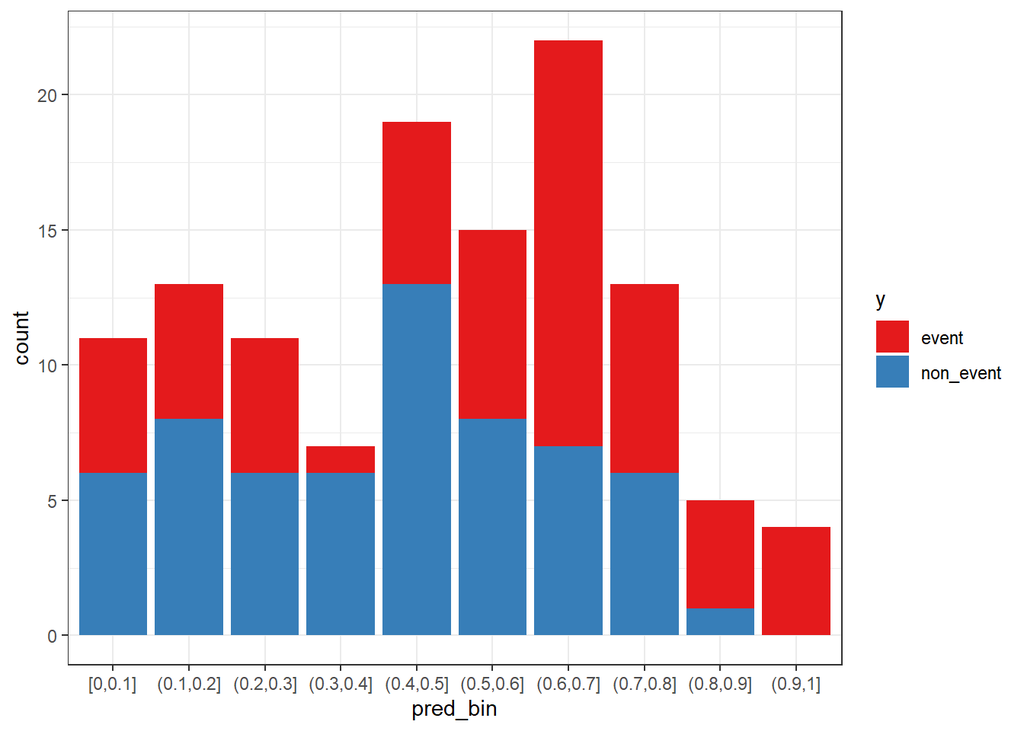

```r
test_df_1_b %>%
  ggplot(mapping = aes(x = pred_bin)) +
  geom_bar(mapping = aes(fill = y)) +
  scale_fill_brewer(palette = "Set1") +
  theme_bw()
```

### 6g)

Instead of showing the counts within each bin, let’s change the bar chart so the maximum height is 1. The stacked bar chart will therefore show the proportion of events and non-events within each predicted probability bin.

**Recreate the stacked bar chart from the previous problem, but this time set the `position` argument to `'fill'` within the `geom_bar()` layer. The `position` argument should be specified outside the `aes()` function with `geom_bar()`. You must continue to map the `fill` aesthetic to the observed outcome.**

**Are the empirical proportions of the event consistent with the predicted probability for model 1?**

*HINT*: Pay close attention to the bar chart colors!

#### SOLUTION

Due to the `scale_fill_*` instruction typo, all you needed to make to receive fill credit is the figure below. The green fill portion from the bottom shows the empirical proportion of non-events per bin. The proportion of events is one minus the green bar height, as represented by the salmon or pink filled bar from the top of the chart. The left most bins correspond to low probability predictions with bin centers at 5%, 15%, and 25%, respectively. However, the observed or empirical event proportions are closer to 40% and 50%. The observations are those **not** consistent with the model predicted probabilities. Our previous bar chart, showed that there are more than 10 observations in each of these three bins. Thus, our empirical results are not simply based on a few measurements.

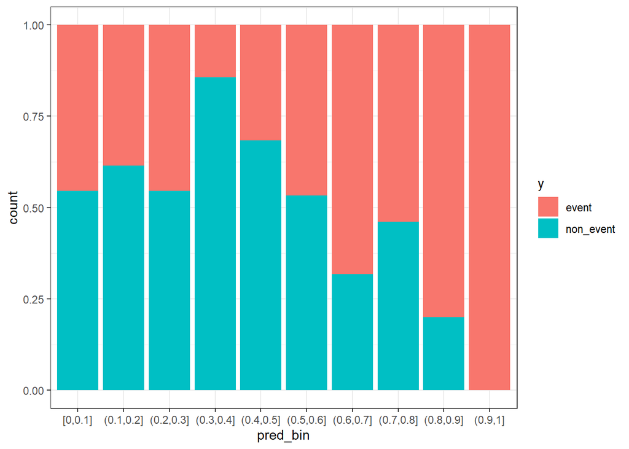

```r
test_df_1_b %>%
  ggplot(mapping = aes(x = pred_bin)) +
  geom_bar(mapping = aes(fill = y),
           position = 'fill') +
  theme_bw()
```

The figure as originally intended to be made with the brewer color palette is shown below.

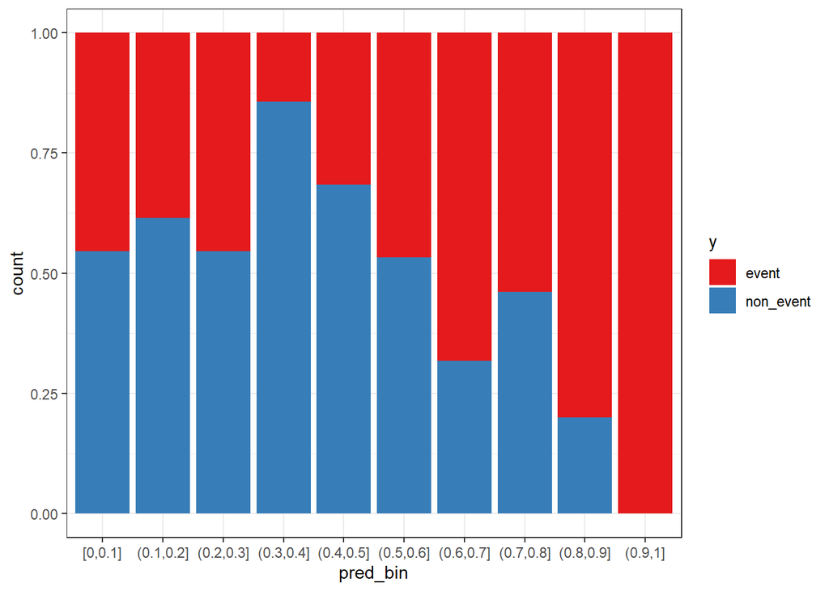

```r
test_df_1_b %>%
  ggplot(mapping = aes(x = pred_bin)) +
  geom_bar(mapping = aes(fill = y),
           position = 'fill') +
  scale_fill_brewer(palette = "Set1") +
  theme_bw()
```

Also, you can reverse the fill ordering so that the event proportion is shown from the bottom rather than the top. You did not have to to do this for this assignment, but the code chunk below shows how to use the `position_fill()` function to accomplish this. As shown below, it’s easier to see the inconsistency between the observed behavior and the predictions when the figure is ordered this way.

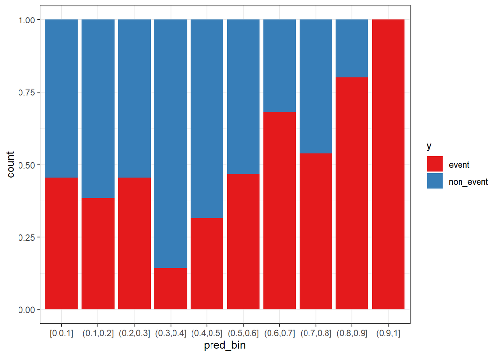

```r
test_df_1_b %>%
  ggplot(mapping = aes(x = pred_bin)) +
  geom_bar(mapping = aes(fill = y),
           position = position_fill(reverse = TRUE)) +
  scale_fill_brewer(palette = "Set1") +
  theme_bw()
```

## Problem 07

The bar chart visualized in Problem 06 is the calibration curve for model 1, but that is not how calibration curves are typically displayed. As shown in lecture, calibration curves are visualized as scatter plots with lines connecting the markers. The previous problem was used to demonstrate the proportion of the event per bin. In this problem, you will calculate the proportion of the event manually in each bin.

This problem is open ended. You are free to calculate the event proportions however you want, as long as you do **NOT** use existing calibration curve functions. You are only allowed to use functions within `dplyr` and `ggplot2` in this problem.

### 7a)

**Calculate the empirical proportion of events within each predicted probability bin associated with model 1. Although you are free to perform the calculations however you like, the results should be stored in a tibble (dataframe) named `my_calcurve_1` object. Your object should have columns for the `pred_bin`, the event proportion in the bin named `prop_event`, and the midpoint of the bin named `mid_bin`. Your `my_calcurve_1` object can have other columns, but those three columns are required.**

#### SOLUTION

There are many ways to go about calculating the event proportion per bin. You do not have to perform the same procedure I show below, but your results must the same as those presented here. The operation is quite simple to perform with the `group_by()` and `summarize()` functions from `dplyr`. These are both common and yet important operations in any data analysis project.

Calculating the event proportion is simple. We just need to use the `mean()` function with the `summarize()` call. The bin mid point though is a little trickier and requires planning. A simple approach requires calculating the maximum and minimum event probability in each bin and then using a `mutate()` call to average them together. This is not equal to the true bin midpoint, but is acceptable for this assignment.

```r
my_calcurve_1 <- test_df_1_b %>%
  group_by(pred_bin) %>%
  summarise(num_obs = n(),
            num_events = sum(y == 'event'),
            prop_event = mean(y == 'event'),
            min_prob = min(event),
            max_prob = max(event),
            .groups = 'drop') %>%
  mutate(mid_bin = 0.5*(min_prob + max_prob))
```

The `my_calccurve_1` tibble has just 10 rows, one row for each bin. As you can see below, the minimum and maximum predicted event probabilities are close to the bin lower and upper bounds. However, they are not exactly equal to those bounds, which is why the estimated bin midpoint is not truly in the middle of each bin.

```r
my_calcurve_1
```

```
## # A tibble: 10 × 7
##    pred_bin  num_obs num_events prop_event min_prob max_prob mid_bin
##    <fct>       <int>      <int>      <dbl>    <dbl>    <dbl>   <dbl>
##  1 [0,0.1]        11          5      0.455   0.0338   0.0991  0.0664
##  2 (0.1,0.2]      13          5      0.385   0.108    0.196   0.152
##  3 (0.2,0.3]      11          5      0.455   0.210    0.298   0.254
##  4 (0.3,0.4]       7          1      0.143   0.338    0.393   0.365
##  5 (0.4,0.5]      19          6      0.316   0.401    0.500   0.451
##  6 (0.5,0.6]      15          7      0.467   0.501    0.569   0.535
##  7 (0.6,0.7]      22         15      0.682   0.601    0.693   0.647
##  8 (0.7,0.8]      13          7      0.538   0.703    0.791   0.747
##  9 (0.8,0.9]       5          4      0.8     0.814    0.880   0.847
## 10 (0.9,1]         4          4      1       0.922    0.955   0.939
```

Another option for adding in the bin midpoint is to create a tibble associated with the unique bin values and manually adding in the bin midpoint. This information could then be joined to the grouped and summarized tibble, as shown below. This approach is rather manual, but is easy to setup since there are just 10 bins.

```r
test_df_1_b %>% distinct(pred_bin) %>%
  arrange(pred_bin) %>%
  mutate(mid_bin = seq(0.05, 0.95, by = 0.1)) %>%
  right_join(test_df_1_b %>%
               group_by(pred_bin) %>%
               summarize(num_obs = n(),
                         num_events = sum(y == 'event'),
                         prop_event = mean(y == 'event'),
                         .groups = 'drop'),
             by = "pred_bin")
```

```
## # A tibble: 10 × 5
##    pred_bin  mid_bin num_obs num_events prop_event
##    <fct>       <dbl>   <int>      <int>      <dbl>
##  1 [0,0.1]      0.05      11          5      0.455
##  2 (0.1,0.2]    0.15      13          5      0.385
##  3 (0.2,0.3]    0.25      11          5      0.455
##  4 (0.3,0.4]    0.35       7          1      0.143
##  5 (0.4,0.5]    0.45      19          6      0.316
##  6 (0.5,0.6]    0.55      15          7      0.467
##  7 (0.6,0.7]    0.65      22         15      0.682
##  8 (0.7,0.8]    0.75      13          7      0.538
##  9 (0.8,0.9]    0.85       5          4      0.8
## 10 (0.9,1]      0.95       4          4      1
```

You were not required to do this, but we could also parse the bin labels directly to extract the lower and upper bounds. Base R includes multiple functions for string manipulation, but I prefer to use `tidyverse` string manipulation found in the `stringr` and `tidyr` packages. Since the instructions specifically said to use only functions from `dplyr` and `ggplot2` you obviously did not have to do this. The following is shown just for your reference.

Rather than using regular expressions to extract the bounds, I prefer to simplify the problem by splitting the string on a common pattern. The `pred_bin` labels have the lower and upper bound separated by a comma. We can thus split or separate the string on the `','` character. The tidyverse way to do this is to use the `tidyr::separate()` function to create additional columns within our dataframe. The resulting columns include the brackets in the bin labels, which are then removed using the `stringr::str_remove()` function. The last step converts the characters to numeric values. The bin midpoint is then easily calculated from the lower and upper bounds.

```r
test_df_1_b %>%
  group_by(pred_bin) %>%
  summarise(num_obs = n(),
            num_events = sum(y == 'event'),
            prop_event = mean(y == 'event'),
            .groups = 'drop') %>%
  tidyr::separate(pred_bin,
                  c("lwr_bin", "upr_bin"),
                  sep =",",
                  remove = FALSE) %>%
  mutate(lwr_bin = stringr::str_remove(lwr_bin, "\\(|\\["),
         upr_bin = stringr::str_remove(upr_bin, "\\]")) %>%
  mutate(across(.cols = c("lwr_bin", "upr_bin"), .fns = as.numeric)) %>%
  mutate(bin_mid = 0.5*(lwr_bin + upr_bin)) %>%
  select(-starts_with("num_"))
```

```
## # A tibble: 10 × 5
##    pred_bin  lwr_bin upr_bin prop_event bin_mid
##    <fct>       <dbl>   <dbl>      <dbl>   <dbl>
##  1 [0,0.1]       0       0.1      0.455    0.05
##  2 (0.1,0.2]     0.1     0.2      0.385    0.15
##  3 (0.2,0.3]     0.2     0.3      0.455    0.25
##  4 (0.3,0.4]     0.3     0.4      0.143    0.35
##  5 (0.4,0.5]     0.4     0.5      0.316    0.45
##  6 (0.5,0.6]     0.5     0.6      0.467    0.55
##  7 (0.6,0.7]     0.6     0.7      0.682    0.65
##  8 (0.7,0.8]     0.7     0.8      0.538    0.75
##  9 (0.8,0.9]     0.8     0.9      0.8      0.85
## 10 (0.9,1]       0.9     1        1        0.95
```

### 7b)

You will now create the calibration curve associated with model 1’s predictions on the hold-out test set! You must use the `my_calcurve_1` object created in Problem 7a).

**Pipe the `my_calcurve_1` object to `ggplot()` and map `mid_bin` and `prop_event` to the `x` and `y` aesthetics, respectively. Include `geom_line()` and `geom_point()` layers and a `geom_abline()` layer. Set the `geom_abline()` arguments as `slope=1`, `intercept=0`, `color='grey'`, and `linetype='dashed'`. Include `coord_equal()` with `xlim = c(0,1)` and `ylim = c(0,1)`.**

**Is the calibration curve consistent with your stacked filled barchart created previously? Pay close attention to the colors in the bar chart when comparing them!**

#### SOLUTION

The calibration curve is created using the approximate bin midpoints rather than the exact mid points. You may have used the exact bin midpoints, but either way the curves will look quite similar. The calibration curve is consistent with our previous chart, though it’s easier to see if the fill positions are reversed. We see that the observed proportion of events is considerably higher than the predicted probability in the first 3 bins, just as we saw with the bar chart.

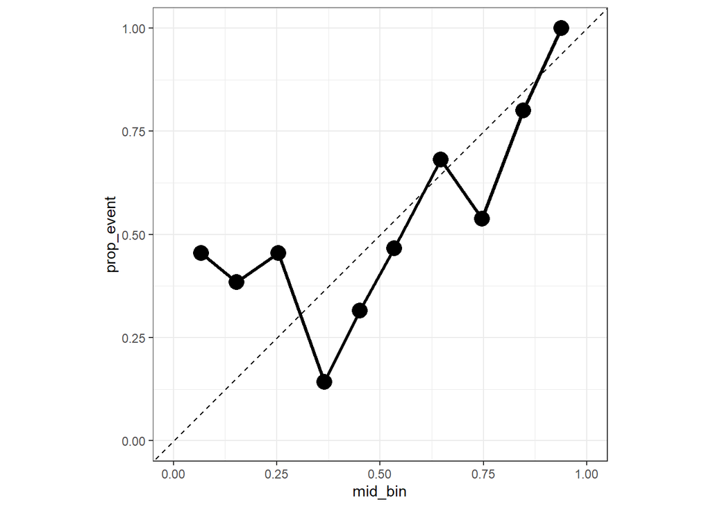

```r
my_calcurve_1 %>%
  ggplot(mapping = aes(x = mid_bin, y = prop_event)) +
  geom_line(size = 1.2) +
  geom_point(size = 5) +
  geom_abline(slope = 1, intercept = 0, linetype = 'dashed') +
  coord_equal(xlim = c(0,1), ylim = c(0, 1)) +
  theme_bw()
```

### 7c)

Now it’s time to create the necessary objects associated with model 3 and model 8. As we started with model 1, we must predict the hold-out test set and return the predicted event probabilities.

**Predict the hold-out test set using model 3 and model 8. Assign the results to the variables `pred_test_3` and `pred_test_8` for model 3 and model 8, respectively.**

#### SOLUTION

```r
pred_test_3 <- predict(mod_3_acc, newdata = df_test, type = 'prob')

pred_test_8 <- predict(mod_8_acc, newdata = df_test, type = 'prob')
```

### 7d)

The code chunk below is completed for you. The model 3 and model 8 predictions are combined with the hold-out test set data so you have the predicted probabilities and observed outcome within a tibble (dataframe). **PLEASE NOTE**: the code chunk below is **NOT** evaluated by default. You must change the `eval` chunk option to make sure the code chunk is executed when you render the report.

```r
test_df_3 <- df_test %>% bind_cols(pred_test_3)

test_df_8 <- df_test %>% bind_cols(pred_test_8)
```

**You must create the categorical predicted probability bins for model 3 and model 8 using the `cut()` function. Assign the results to the `test_df_3_b` and `test_df_8_b` objects for model 3 and model 8, respectively.**

#### SOLUTION

```r
test_df_3_b <- test_df_3 %>%
  mutate(pred_bin = cut(event,
                        breaks = seq(0, 1, by = 0.1),
                        include.lowest = TRUE))

test_df_8_b <- test_df_8 %>%
  mutate(pred_bin = cut(event,
                        breaks = seq(0, 1, by = 0.1),
                        include.lowest = TRUE))
```

### 7e)

**Use `ggplot2` to visualize the number of observations per bin for model 3 with a bar chart.**

#### SOLUTION

As shown below, most of the bins contain roughly 10 observations. The lowest count is 6 in the 15% midpoint bin.

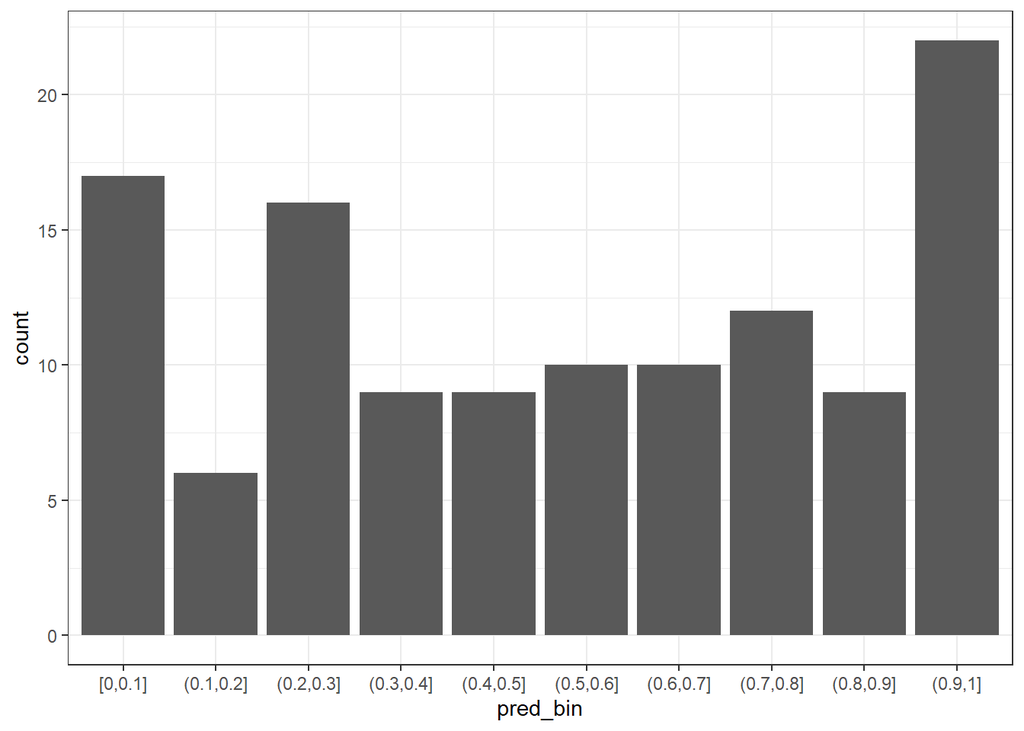

```r
test_df_3_b %>%
  ggplot(mapping = aes(x = pred_bin)) +
  geom_bar() +
  theme_bw()
```

### 7f)

**Use `ggplot2` to visualize the number of observations per bin for model 8 with a bar chart.**

#### SOLUTION

The predictions from model 8 do NOT include all bins! As shown in the figure below, there are only 5 bins present. Most of the observations are contained in a single bin and so we can conclude that model 8 mostly predicts an event probability near 45% on the test set.

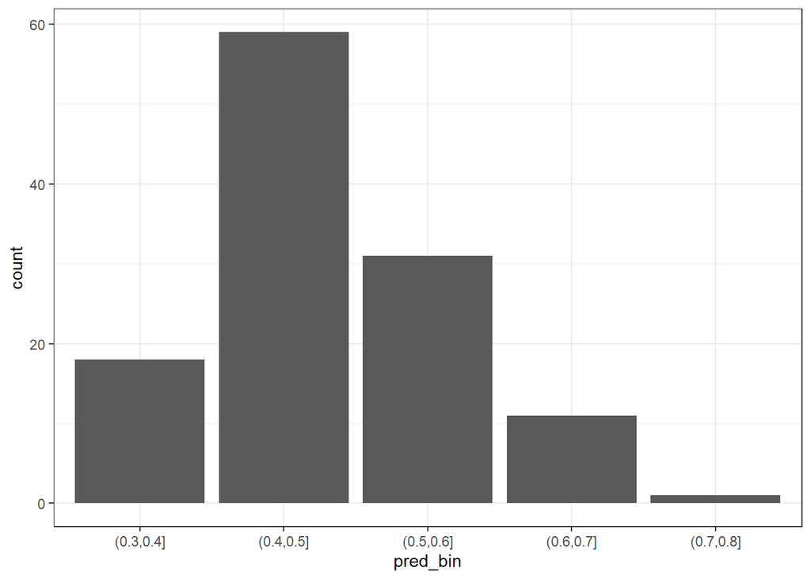

```r
test_df_8_b %>%
  ggplot(mapping = aes(x = pred_bin)) +
  geom_bar() +
  theme_bw()
```

## Problem 08

Rather than using the stacked filled bar charts to represent the calibration curve for models 3 and 8, let’s jump straight to creating the calibration curve object for the two models.

### 8a)

**Calculate the empirical proportion of events within each predicted probability bin associated with model 3. Although you are free to perform the calculations however you like, the results should be stored in a tibble (dataframe) named `my_calcurve_3` object. Your object should have columns for the `pred_bin`, the event proportion in the bin named `prop_event`, and the midpoint of the bin named `mid_bin`. Your `my_calcurve_3` object can have other columns, but those three columns are required.**

#### SOLUTION

The model 3 calibration curve is created with `group_by()` and `summarize()` following the same steps described for model 1. The approximate bin midpoint is calculated, but we could use the exact bin midpoint if we preferred.

```r
my_calcurve_3 <- test_df_3_b %>%
  group_by(pred_bin) %>%
  summarise(num_obs = n(),
            num_events = sum(y == 'event'),
            prop_event = mean(y == 'event'),
            min_prob = min(event),
            max_prob = max(event),
            .groups = 'drop') %>%
  mutate(mid_bin = 0.5*(min_prob + max_prob))
```

### 8b)

**Calculate the empirical propotion of events within each predicted probability bin associated with model 8. Although you are free to perform the calculations however you like, the results should be stored in a tibble (dataframe) named `my_calcurve_8` object. Your object should have columns for the `pred_bin`, the event proportion in the bin named `prop_event`, and the midpoint of the bin named `mid_bin`. Your `my_calcurve_8` object can have other columns, but those three columns are required.**

#### SOLUTION

The calibration curve for model 8 is calculated below.

```r
my_calcurve_8 <- test_df_8_b %>%
  group_by(pred_bin) %>%
  summarise(num_obs = n(),
            num_events = sum(y == 'event'),
            prop_event = mean(y == 'event'),
            min_prob = min(event),
            max_prob = max(event),
            .groups = 'drop') %>%
  mutate(mid_bin = 0.5*(min_prob + max_prob))
```

### 8c)

**Visualize the calibration curve for model 3 using the approach described in Problem 7b).**

#### SOLUTION

The calibration curve associated with model 3 has most of the bins following the “45-degree” line, as shown in the figure below. Only 1 bin shows inconsistencies between the predictions and the observed outcome. Otherwise, the calibration curve reveals the model appears to represent the event probability quite well!

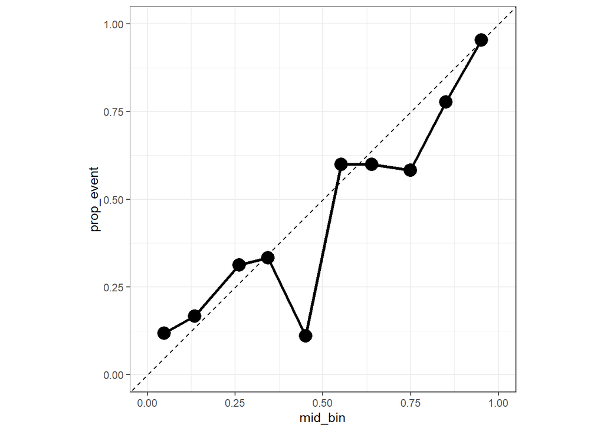

```r
my_calcurve_3 %>%
  ggplot(mapping = aes(x = mid_bin, y = prop_event)) +
  geom_line(size = 1.2) +
  geom_point(size = 5) +
  geom_abline(slope = 1, intercept = 0, linetype = 'dashed') +
  coord_equal(xlim = c(0,1), ylim = c(0, 1)) +
  theme_bw()
```

### 8d)

**Visualize the calibration curve for model 8 using the approach described in Problem 7b).**

#### SOLUTION

The calibration curve for model 8 is different from the other two. Although the data appear consistent with the binned predicted probability, we do not have a complete curve! Model 8 is essentially predicting probabilities around 50%. The highest predicted probability bin associated with model 8 is the 75% bin. That bin is not consistent with the observations, although as shown previously that bin has low sample size. Essentially, model 8 is relatively consistent, but it’s consistent with saying there’s roughly a 50% chance the event occurs. Model 8 is therefore just saying there’s a “coin flip” chance and is not capable of resolving low and high event probabilities!

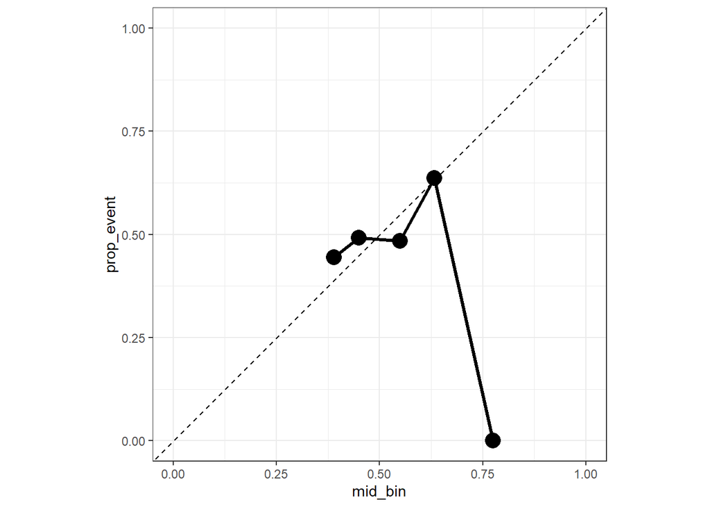

```r
my_calcurve_8 %>%
  ggplot(mapping = aes(x = mid_bin, y = prop_event)) +
  geom_line(size = 1.2) +
  geom_point(size = 5) +
  geom_abline(slope = 1, intercept = 0, linetype = 'dashed') +
  coord_equal(xlim = c(0,1), ylim = c(0, 1)) +
  theme_bw()
```

### 8d)

**Based on your calibration curves, which of the three models appears the most well calibrated? Is it easy obvious which model performs better using this approach? What are the most obvious aspects of performance based on your calibration curves?**

#### SOLUTION

The calibration curve is a graphical tool that works similar to the predicted-vs-observed figure in regression. The ideal model has the empirical event proportion correlated with the binned predicted event probability. We are thus looking for the calibration curve to fall along the “45-degree” line.

Another way to view this, is we need to consider the performance in the context of other models. Model is not only consistent, but it captures a much larger range of the event probabilities. Model 3 is thus able to identify when the even has a small chance of occurring and a very high chance of occurring.

To help with the comparison, let’s put all three models together onto a single graphic. You were not required to do this to receive full credit, but seeing the comparison this way can help with the interpretation. As shown below, model 3 only has one bin with substantial inconsistency with the observations. Model 8 is not capable of resolving any behavior outside roughly 50% probabilities.

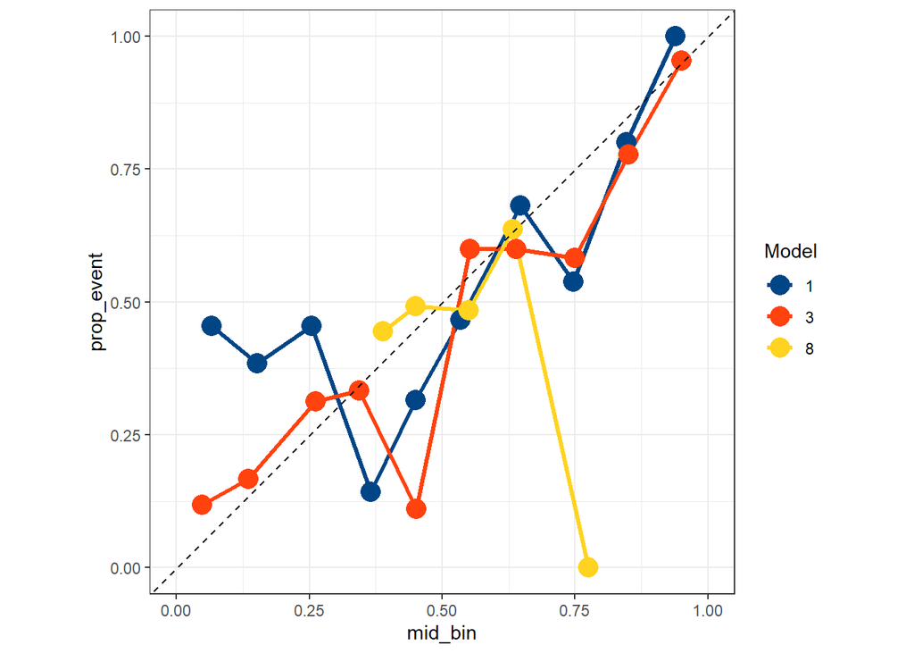

```r
my_calcurve_1 %>%
  mutate(model = 1) %>%
  bind_rows(my_calcurve_3 %>% mutate(model = 3)) %>%
  bind_rows(my_calcurve_8 %>% mutate(model = 8)) %>%
  ggplot(mapping = aes(x = mid_bin, y = prop_event)) +
  geom_line(size = 1.2,
            mapping = aes(color = as.factor(model))) +
  geom_point(size = 5,
             mapping = aes(color = as.factor(model))) +
  geom_abline(slope = 1, intercept = 0, linetype = 'dashed') +
  coord_equal(xlim = c(0,1), ylim = c(0, 1)) +
  ggthemes::scale_color_calc("Model") +
  theme_bw()
```

The calibration curve is a useful graphical tool for understanding model behavior. However, it can be tricky to compare multiple models based on the calibration. Unless there are clear and obvious differences as between the models (as we saw in this case) it is not as straight forward for model selection compared to other metrics. That said, I like to use the calibration curve as a tool to help understand model predictions. For example, the calibration curve tells us that model 8 only predicts probabilities in a narrow interval. It is always important to interpret the model predictive behavior. The calibration curve is one such approach for helping with that interpretation.

## Problem 09

Calibration curves are created by executing many tedious steps. Although you had to perform those steps manually in this assignment there are existing functions which perform the necessary calculations for you. One such function is the `caret::calibration()` function. You will use that function in this problem to practice easily creating calibration curves. The `caret::calibration()` function works with resampled results, but for consistency with the previous problems, we will use with the hold-out test set predictions associated with the `df_test` data set.

The `caret::calibration()` function has 3 main arguments. The first argument is a formula, the second argument is the data set, and third is the number of bins to use. The formula follows a specific pattern:

`<binary output variable> ~ <event probability variable>`

The formula therefore gives the binary outcome variable name to the **left** of the tilde and the variable name for the event probability to the **right** of the tilde. These names **must** match the column names in the data set assigned to the `data` argument. The number of bins is specified by the `cuts` argument.

### 9a)

**Create the calibration curve associated with model 1’s hold-out test predictions using the `caret::calibration()` function. Specify the formula to be consistent with the `test_df_1` data set. Assign the `test_df_1` object to the `data` argument and assign `cuts = 10`. Pipe the result to the `xyplot()` function.**

**Is the created calibration curve consistent with your manually created curve from the previous problems?**

#### SOLUTION

The formula must use variable names that are contained within the provided data set. The binary outcome variable is named `y` and the event probability is contained in the `event` column. If you ever forget, it’s best to just check the column names to be sure. A glimpse of the test data set predictions is shown below as a reminder.

```r
test_df_1 %>% glimpse()
```

```
## Rows: 120
## Columns: 7
## $ x1        <dbl> -0.226126900, 1.573924144, -1.054455037, 0.083051357, 0.4245…
## $ x2        <dbl> -0.3361453, 0.5445463, 0.5837157, -0.8979020, -0.6339053, -0…
## $ x3        <dbl> -1.22092445, -0.41352769, 2.45375479, -0.31070519, 0.4087187…
## $ x4        <dbl> 0.59734091, 1.16494692, 0.41455929, 0.03209814, -0.91177742,…
## $ y         <fct> event, non_event, non_event, non_event, non_event, non_event…
## $ event     <dbl> 0.2607671, 0.7113031, 0.7467320, 0.1964256, 0.3579798, 0.286…
## $ non_event <dbl> 0.73923285, 0.28869689, 0.25326803, 0.80357436, 0.64202020, …
```

The `caret::calibration()` function is executed and the result is piped to `xyplot()` in the code chunk below. The resulting figure is consistent with the calibration curves we manually created earlier! The only difference is the `xyplot()` shows the event proportion and bin midpoint as percentages rather than fractions. We see the same behavior with the empirical event proportions much higher than the model 1 predictions for the first 3 bins, and the empirical proportion lower than the model 1 predictions in the next few bins.

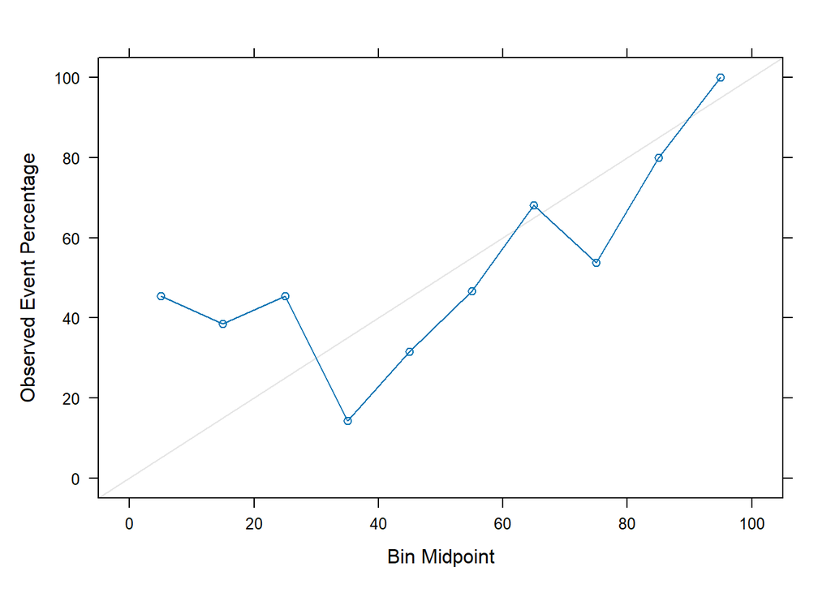

```r
caret::calibration(y ~ event, data = test_df_1, cuts = 10) %>%
  xyplot()
```

If you were confused about the formula interface in this problem, look closely at the order presented in the formula. The `y` variable - the binary outcome - is the left of `~`, while `event` - the model predicted probability - is the right of `~`. The formula therefore reads as “`y` is on the y-axis” and “`event` is on the x-axis”. The formula is therefore stating what variables contribute to each axis.

Also, just to show it, the `test_df_1` object can be piped into `caret::calibration()`. The first argument must be the formula and so we can force the piped object to be used as the second argument with the `.` operator, as shown below.

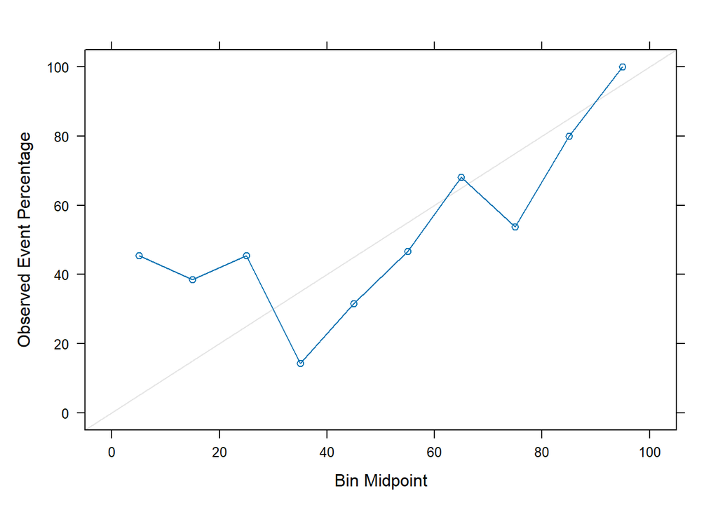

```r
test_df_1 %>%
  caret::calibration(y ~ event, data = ., cuts = 10) %>%
  xyplot()
```

### 9b)

**Create the calibration curve associated with model 3’s hold-out test predictions using the `caret::calibration()` function. Specify the formula to be consistent with the `test_df_3` data set. Assign the `test_df_3` object to the `data` argument and assign `cuts = 10`. Pipe the result to the `xyplot()` function.**

**Is the created calibration curve consistent with your manually created curve from the previous problems?**

#### SOLUTION

The calibration curve associated with model 3 is shown below. It is also consistent with what we made previously! Only 1 bin appears substantially away from the “45-degree” line.

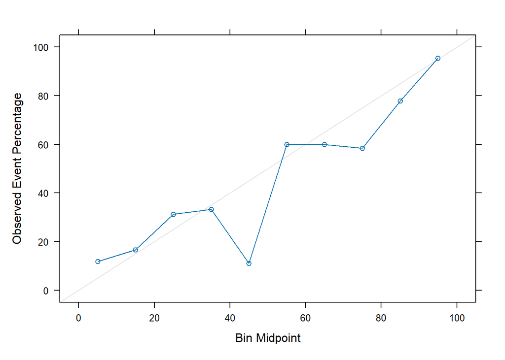

```r
caret::calibration(y ~ event, data = test_df_3, cuts = 10) %>%
  xyplot()
```

### 9c)

**Create the calibration curve associated with model 8’s hold-out test predictions using the `caret::calibration()` function. Specify the formula to be consistent with the `test_df_8` data set. Assign the `test_df_8` object to the `data` argument and assign `cuts = 10`. Pipe the result to the `xyplot()` function.**

**Is the created calibration curve consistent with your manually created curve from the previous problems?**

#### SOLUTION

The calibration curve associated with model 8 is displayed below. As we can see, the `xyplot()` result shows all bins, even though our manually created figure did not include all bins for model 8. The calibration curve below is not “wrong”. However, if we only relied on this auto-generated plot, we could incorrectly determine the there are zero events when the model predicts an event probability of about 25%. This is not the case. As we saw with our manually created figure, the model does not predict probabilities below 30%! Thus, it’s not there is an inconsistency, it’s the model is not capable of of that behavior. This demonstrates that it can be useful to always check our assumptions of the behavior of an existing method!

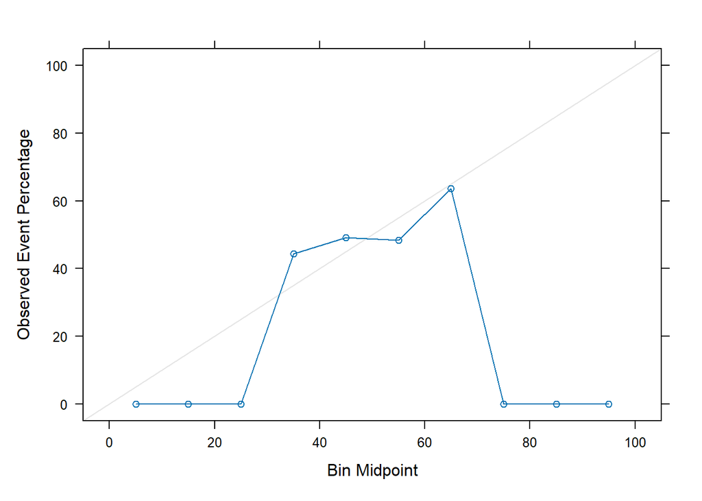

```r
caret::calibration(y ~ event, data = test_df_8, cuts = 10) %>%
  xyplot()
```

You were not required to do this, but the code chunk below shows how to compile all three calibration curves together into a single figure.

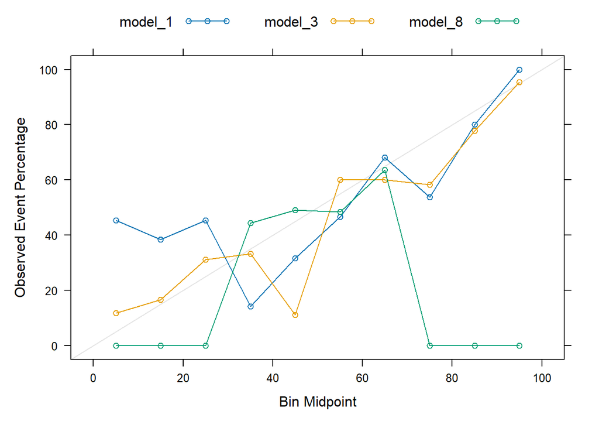

```r
test_df_1 %>%
  select(y, model_1 = event) %>%
  tibble::rowid_to_column() %>%
  left_join(test_df_3 %>%
              select(y, model_3 = event) %>%
              tibble::rowid_to_column(),
            by = c("rowid", "y")) %>%
  left_join(test_df_8 %>%
              select(y, model_8 = event) %>%
              tibble::rowid_to_column(),
            by = c("rowid", "y")) %>%
  caret::calibration(y ~ model_1 + model_3 + model_8, data = ., cuts = 10) %>%
  xyplot(auto.key = list(columns = 3))
```